G4VMscModel.

In the majority of use-cases when new EM physics is needed, it is enough

to create only a new model class and use it in the existing EM process class.

A new model may be added to an existing process using

Hadronic

[figure not shown]

The hadronic physics of Geant4 has been designed to allow three basic

types of modelling: data-driven, parameterisation-driven, and theory-driven.

Five implementation frameworks have been used to allow great flexibility

in these modelling approaches. An overview of the first two framework

levels will be given here (for a wider and more detailed coverage please

refer to the next Chapter).

The top-level framework defines the hadronic processes, and provides the

basic interface to other Geant4 categories. All processes have a common

base-class G4VProcess, from which a set of specialised classes are derived.

Two of them are used as base classes for hadronic processes for particles

(G4VDiscreteProcess), and for processes like radioactive decay that can be

declares two types of methods: one for calculating the time to interaction

(for at-rest processes) or the physical interaction length (for in-flight

processes), allowing tracking to request the information necessary to decide

on the process responsible for final-state production.

Note on at-rest processes: starting with Geant4 version 9.6 - when the

Bertini and Fritiof final-state models have been extended down to zero

kinetic energy and used also for simulating the nuclear capture at-rest - the

at-rest processes derive from G4HadronicProcess, hence from

G4VDiscreteProcess, instead than from G4VRestProcess as in the initial

design of at-rest processes. This requires some adaptation a discrete process

to handle an at-rest one using top level interface G4VProcess. A different

solution, under consideration but not yet implemented, would be instead to

have G4HadronicProcess inheriting from G4VRestDiscreteProcess: in this

way, G4HadronicProcess, and therefore any theory-driven final-state

model, could be deployed for any kind of hadronic process, including

capture-at-rest processes and radioactive decays.

The class diagram is shown in the Fig. 9.

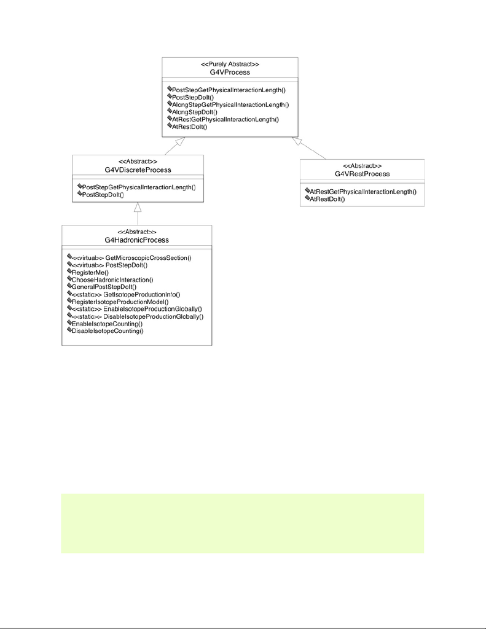

Fig. 9 First level implementation framework of the hadronic category of

Geant4.

Whenever possible, it is preferable to add any new hadronic physics to

Geant4 in terms of a model, and assign the model to an existing process,

rather than develop a new, specific process. However, in some cases, a

directly implemented hadronic process may be necessary. In these cases, the

new process must derive from G4HadronicProcess and the following three

methods must be implemented:

virtual G4VParticleChange* PostStepDoIt(const G4Track&, const

G4Step&) ,

virtual G4bool IsApplicable(const G4ParticleDefinition&) ,

G4double GetMeanFreePath(const G4Track& aTrack, G4double,

G4ForceCondition*) .

[figure not shown]

More details on these methods will be provided in the next Chapter.

At the next level of abstraction, only processes that occur for particles in

flight are considered. For these, the main design requirement is to treat

cross sections and the final-state models (i.e. the models responsible for the

production of the secondaries) independently, so that it is possible to change

cross section while keeping a particular final-state model, or, vice versa, to

keep a given cross section while replacing the final-state model. Moreover,

a set of cross sections can be used for a single hadronic process to cover a

wide kinematical range (e.g. from thermal energies up to several tera-

electronvolts of the projectile kinetic energy). Similarly, for the same

reason, a set of different final-state models can be used for a single hadronic

process, allowing the overlapping between two models in an interval of the

projectile kinetic energy, to insure a smooth transition between these

models.

The class diagram for hadronic cross-sections is shown in Fig. 10 and in

Fig. 11 for final-state models.

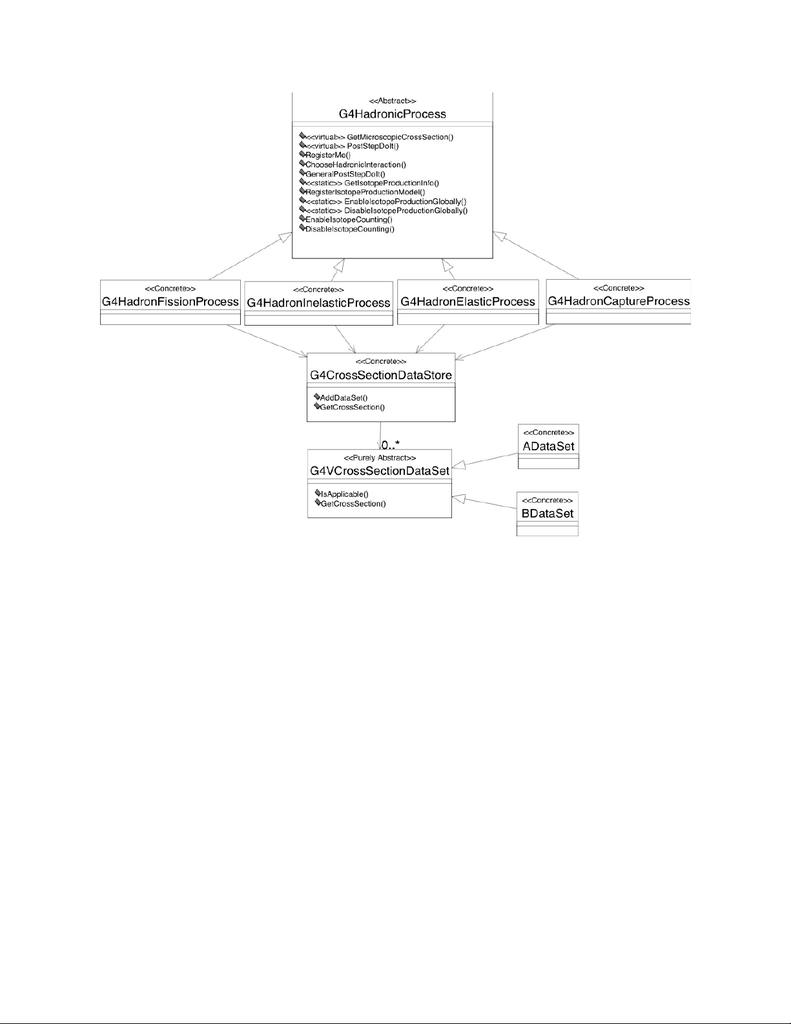

Fig. 10 Second level implementation framework of the hadronic category of

Geant4: cross-section aspect.

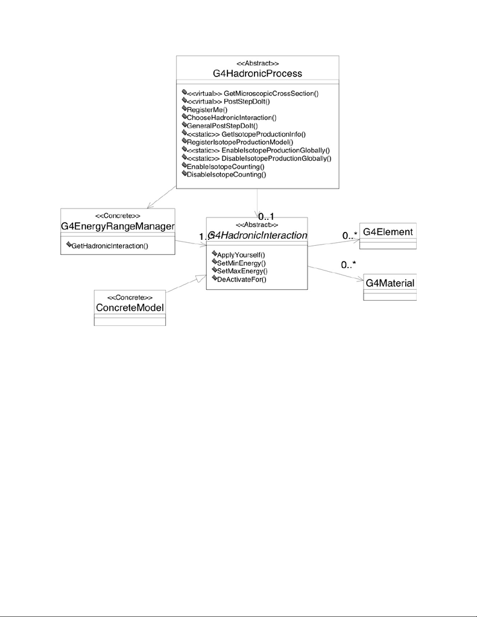

Fig. 11 Second level implementation framework of the hadronic category of

Geant4: final-state production aspect.

Each hadronic process is derived from G4HadronicProcess, which holds a

list of "cross section data sets". All cross section data set classes are derived

from the abstract class G4VCrossSectionDataSet. The process stores and

retrieves the data sets through a data store that acts like a FILO (First-In-

Last-Out) stack. Details on how to write a new hadronic cross section set

will be provided in the next Chapter.

The G4HadronicProcess class provides a registration service for classes

deriving from G4HadronicInteraction, and delegates final-state

production to the applicable model. Models inheriting from

G4HadronicInteraction can be restricted in applicability in projectile type

and energy, and can be activated/deactivated for individual materials and

elements. Details on how to write a new hadronic final-state model will be

provided in the next Chapter.

Footnotes

[figure not shown]

Hits and Digitisation

Design Philosophy

In Geant4 a hit is a snapshot of a physical interaction or an accumulation of

interactions of a track or tracks in a "sensitive" detector component. A

digitisation, or digit, represents a detector output, such as an ADC/TDC

count or a trigger signal. A digit is created from one or more hits and/or

other digits.

Given the wide variety of Geant4 applications, ways of describing detector

sensitivity and the quantities to be stored in the hits and digits vary greatly.

This category therefore provides only abstract classes for both detector

sensitivity and hits/digits. It also provides tools for organising the hits/digits

into collections.

Class Design

G4VHit - this class has all the information about a particular hit

caused by a single step.

G4VHitsCollection - base class for a collection of hits.

G4THitsCollection - template class for a collection of hits of the

(template) type. Implements G4VHitsCollection interface providing

efficient storage of hits via allocators.

G4HCofThisEvent - container class for collections of hits for the

current event.

G4VSensitiveDetector - pure virtual class representing a sensitive

element responsible for creating and managing associated hits. The

user should implement the method ProcessHits a filter and readout

geometry (optional) are also allowed.

G4SDManager - singleton managing sensitive detectors.

G4SDMessenger - SD manager associated messenger.

G4SDStructure - used exclusively used by G4SDManager for

handling the tree structure of the user's sensitive detector names. Each

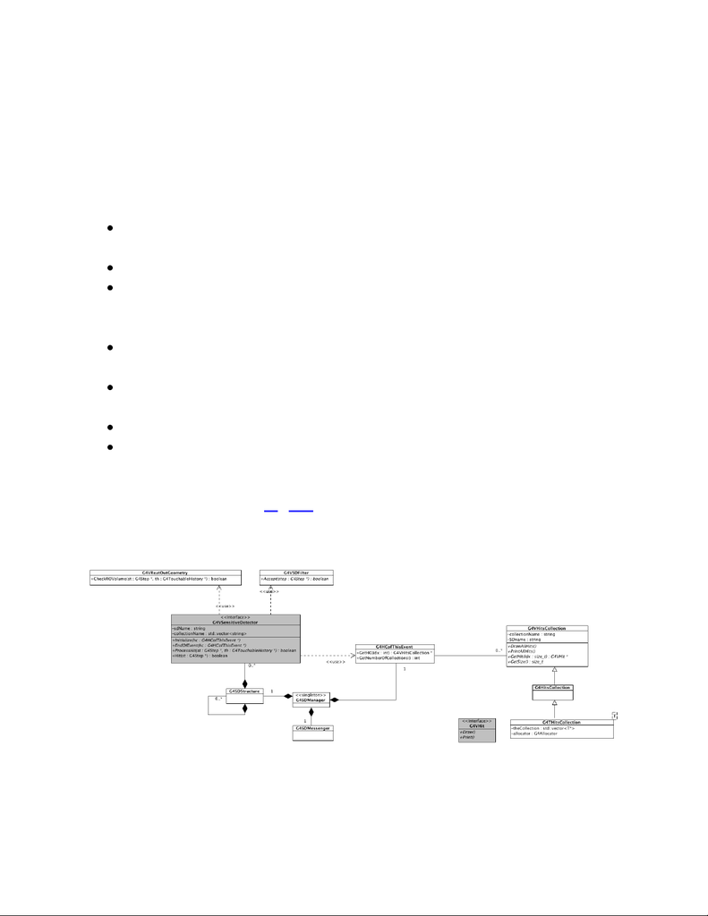

branch represents the hits in given sub-detector. For example, the first

level of branches may consist of a tracker, ECAL, and HCAL, while

the second level, in HCAL, consists of the barrel and endcaps. Finally

the barrel may have phi-slices, Z-slices, etc.

For digitisation features a similar design as for hits is applied:

G4VDigi - an abstract (base) class for all G4 digitisations. This could

be data as simple as a singe byte, or as complex as an Ntuple.

G4VDigiCollection - base class for a collection of digits.

G4TDigiCollection - template class for a collection of digits of the

(template) type. Implements G4VDigiCollection interface providing

efficient storage of digits via allocators.

G4DCofThisEvent - container class for collections of digits for the

current event.

G4VDigitizerModule - the class of objects which transform the hits

deposited by particles into digitisations.

G4DigiManager - singleton managing digitiser modules.

G4DigiMessenger - Digi manager associated messenger.

The UML class diagram for sensitivity related classes is shown in the

following class diagram. Fig. 12 shows the general management of hit

classes.

Fig. 12 Overview of hit classes management. Classes in grey represent the

main components that a user must subclass to implement a sensitive

detector. User is also responsible of creating the binding between

G4THitsCollection and its hit class.

Footnotes

Geometry

Design Philosophy

The geometry category provides the ability to describe a geometrical

structure and propagate particles efficiently through it. This is done in part

with the aid of two central concepts, the logical and physical volumes. A

logical volume represents a detector element of a given shape which may

contain other volumes, and which may have other attributes. It has access to

other information which is independent of its physical location in the

detector, such as material and sensitive detector behaviour. A physical

volume represents the spatial positioning or placement of the logical

volume with respect to an enclosing mother (logical) volume. Thus a

hierarchical tree structure of volumes can be built with each volume

containing smaller volumes (which may not overlap). Repetitive structures

can be represented by specialised physical volumes, such as replicas and

parameterised placements, sometimes resulting in a large savings in

memory.

In Geant4 the logical volume has been refined by defining the shape as a

separate entity, called a solid. Solids with simple shapes, like rectilinear

boxes, trapezoids, spherical or cylindrical sections or shells, each have their

properties coded separately, in accord with the concept of Constructed Solid

Geometry (CSG). More complex solids are defined for specific use, or

having their surfaces approximated by facets (tessellated solids).

Another way to build solids is by Boolean combination - union, intersection

and subtraction. The elemental solids should be CSGs.

Although a detector is naturally and best described as by a hierarchy of

volumes, efficiency is not critically dependent on this. An optimisation

technique, called voxelization, allows efficient navigation even in "flat"

geometries, typical of those produced by CAD systems.

[figure not shown]

Class Design

G4GeometryManager - responsible for managing "high level"

objects in the geometry subdomain, notably including opening and

closing ("locking") the geometry, and creating/deleting optimisation

information for G4Navigator. The class is a "singleton".

G4LogicalVolumeStore - a container for optionally storing created

logical volumes. It enables traversal of all logical volumes by the

UI/user/etc.

G4LogicalVolume - represents a leaf node or unpositioned subtree in

the geometry hierarchy. It may have daughters ascribed to it, and is

also responsible for retrieval of the physical and tracking attributes of

the physical volume that it represents. These attributes include solid,

material, magnetic field, and optionally user limits, sensitive detectors,

etc. Logical volumes are optionally entered into the

G4LogicalVolumeStore.

G4MagneticField - a class responsible for the magnetic field in each

volume, including the calculation of particle trajectories along curved

paths. In cases where the geometry step limits the particle's step, the

distance calculated is guaranteed to be the distance to a volume

boundary.

G4Navigator - a class used by the tracking management, able to

obtain/calculate tracking-time geometrical information such as

distance to the next volume, or to find the physical volume containing

a given point in the world reference system. The navigator maintains a

transformation history and other information used to optimise the

tracking time performance.

G4NavigationHistory - responsible for maintenance of the history of

the path taken through the geometrical hierarchy. It is principally a

utility class for use by G4Navigator.

G4NormalNavigation - a utility class for navigation in volumes

containing only G4PVPlacement daughter volumes.

G4ParameterisedNavigation - a utility class for navigation in

volumes containing a single G4PVParameterised volume for which

voxels for the replicated volumes have been constructed.

G4VoxelNavigation - a utility class for navigation in volumes

containing only G4PVPlacement daughter volumes for which voxels

[figure not shown]

have been constructed.

G4ReplicaNavigation - a utility class for navigation in volumes

G4PhysicalVolumeStore - a container for optionally storing created

physical volumes. It enables traversal of all physical volumes by the

UI/user/etc. All solids should be registered with

G4PhysicalVolumeStore, and removed on their destruction. It is

intended principally for the UI browser.

G4VPhysicalVolume - a volume positioned within and relative to a

given mother volume, and also represented by a given logical volume.

They are optionally entered into the G4PhysicalVolumeStore.

G4PVPlacement - a physical volume corresponding to a single

touchable detector element, positioned within and relative to a mother

volume.

G4PVReplica - a physical volume representing many identically

formed touchable detector elements, differing only in their positioning.

The elements' positions are determined by means of a simple formula,

and the elements completely fill the containing mother volume.

G4PVParameterised - a physical volume representing many

touchable detector elements differing in their positioning and

dimensions. Both are calculated by means of a G4VParameterisation

object. Each element's position is calculated as per G4PVReplica, and

each element's shape can be modified by means of a user supplied

formula.

G4VPVParameterisation - a parameterisation class able to compute

the transformation and, indirectly, the dimensions of parameterised

volumes, given a replication number.

G4SmartVoxelProxy - a class for proxying smart voxels. The class

represents either a header (in turn referring to more VoxelProxies) or a

node. If created as a node, calls to GetHeader cause an exception, and

likewise GetNode when a header.

G4SmartVoxelHeader - represents a single axis of virtual division.

Contains the individual divisions which are potentially further divided

along different axes.

G4SmartVoxelNode - a single virtual division, containing the

physical volumes inside its boundaries and those of its parents.

[figure not shown]

G4VoxelLimits - represents limitation/restrictions of space, where

restrictions are only made perpendicular to the Cartesian axes.

G4SolidStore - a container for optionally storing created solids. It

enables traversal of all/any solids by the UI/user/etc. The class is a

"singleton".

G4VSolid - position independent geometrical entities. They have only

'shape', and encompass both CSG and boundary representations. They

are optionally entered into the G4SolidStore. This class defines, but

does not implement, functions to compute distances to/from the shape.

Functions are also defined to check whether a point is inside the shape,

to return the surface normal of the shape at a given point, and to

compute the extent of the shape.

G4VTouchable - a class that maintains a "reference" on a given

touchable element of the detector - a kind of bookmark. It enables a

given detector element to be saved during tracking (in case of

Booleans/user code/etc.) and the corresponding G4PhysicalVolume

retrieved later, with its "state" information (path through the tree)

optionally restored so that navigation can be restarted. G4Touchables

provide fast access to the transformation from the global reference

system to that of the saved detector element.

G4TouchableHistory - object representing a touchable detector

element, and its history in the geometrical hierarchy, including its net

resultant local->global transform.

G4GRSSolid - object representing a touchable solid. It maintains the

association between a solid and its net resultant local-to-global

transform.

G4GRSVolume - object representing a touchable detector element. It

maintains associations between a physical volume and its net resultant

local-to-global transform.

G4AffineTransform - a class for geometric affine transformations. It

supports efficient arbitrary rotation and transformation of vectors and

the computation of compound and inverse transformations. A "rotation

flag" is maintained internally for greater computational efficiency for

transforms that do not involve rotation.

G4UserLimits - responsible for user limits on step size, ascribable to

individual volumes.

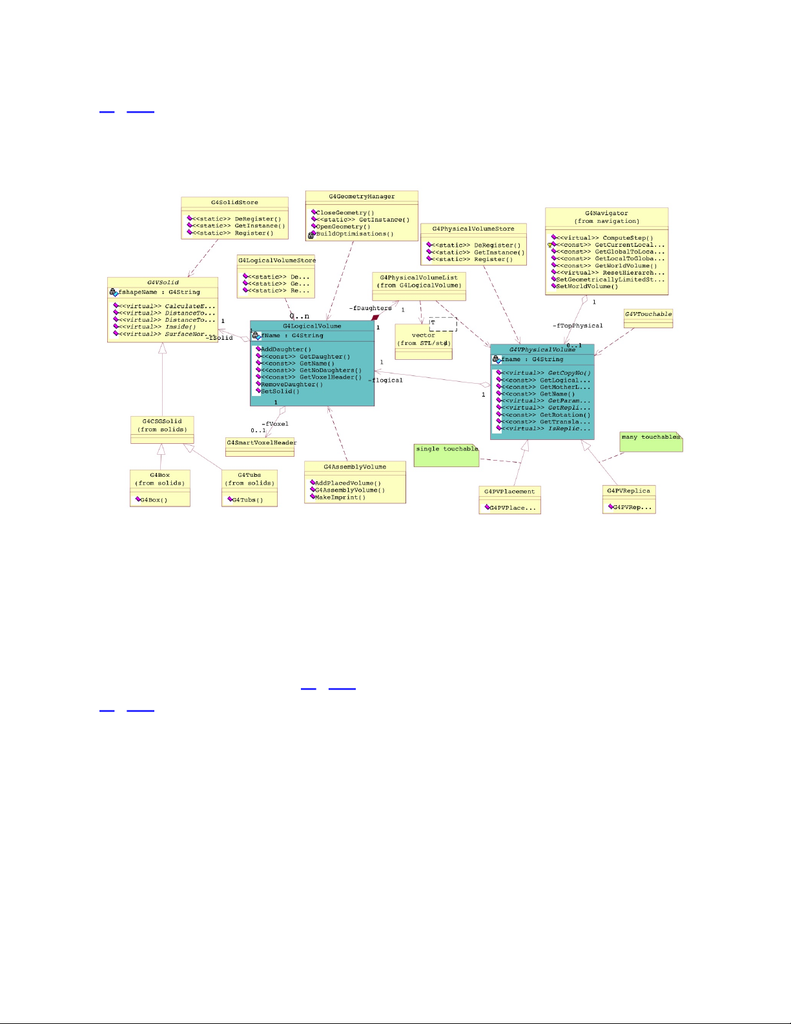

Fig. 13 shows a general overview, in UML notation, of the geometry

design. A detailed collection of class diagrams from the geometry category

is found in the Appendix.

Fig. 13 Overview of the geometry.

Additional Geometry Diagrams

Additional diagrams for the object-oriented design of the 'geometry' related

classes are included here. Fig. 14 shows the class diagram for smart voxels.

Fig. 15 shows the class diagram for the navigator.

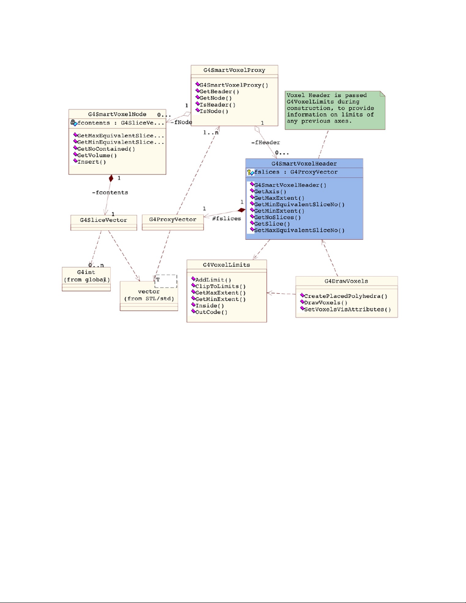

Fig. 14 Class diagram for smart voxels

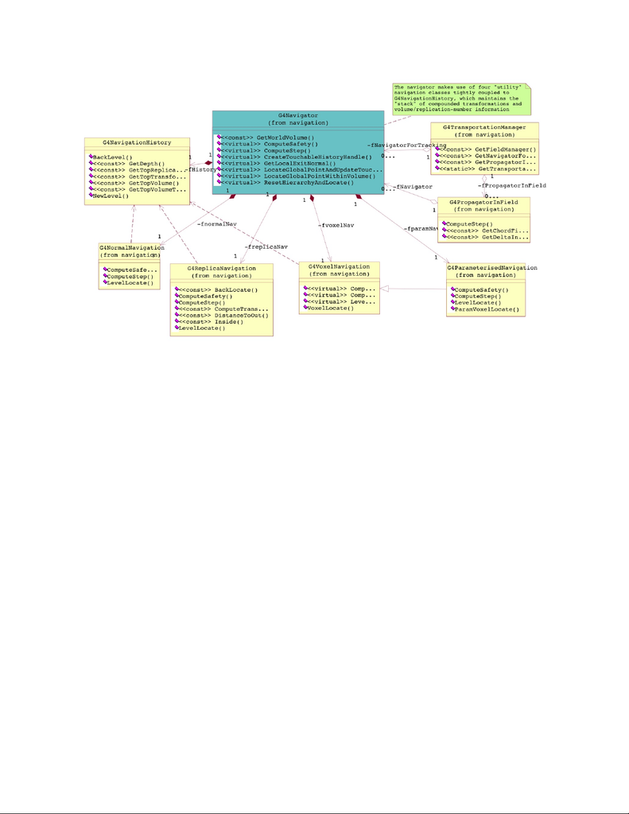

Fig. 15 Class diagram for the navigator

Footnotes

[figure not shown]

Electromagnetic Fields

Class Design

G4TransportationManager - singleton class storing the (volume)

navigator used by the transportation process to do the geometrical

tracking. It also stores a pointer to the propagator used in a (magnetic)

field and to the field manager. The class instance is created before

main() is called, and in turn creates the navigator and the rest.

G4PropagatorInField - class performing the navigation/propagation

of a particle/track in a magnetic field. The field is in general non-

uniform. For the calculation of the path, it relies on the class

G4ChordFinder.

G4FieldManager - class managing (storing) a pointer to the Field

subclass that describes the field of a detector (magnetic, electric or

other). Also stores a reference to the chord finder. The

G4FieldManager class exists to allow the user program to specify the

electric, magnetic and/or other field(s) of the detector. A field manager

can be set to a logical volume (or to more than one), in order to vary its

field from that of the world. In this manner a zero or constant field can

override a global field, a more or less exact version can override the

external approximation, lower or higher precision for tracking can be

specified, a different stepper can be chosen for different volumes, ... It

also stores a pointer to the G4ChordFinder object that can do the

propagation in this field. G4FieldManager allows the other

classes/object (of the MagneticField and other class categories) to find

out whether a detector field object exists and what that object is. A

default G4FieldManager is created by the singleton class

G4NavigatorForTracking and exists before main is called. However a

new one can be created and given to G4NavigatorForTracking. Our

current design envisions that one G4FieldManager is valid for each

region detector.

G4ChordFinder - class providing the integration of motion using the

ODE solver's driver to find the end-point that satisfies the chord length

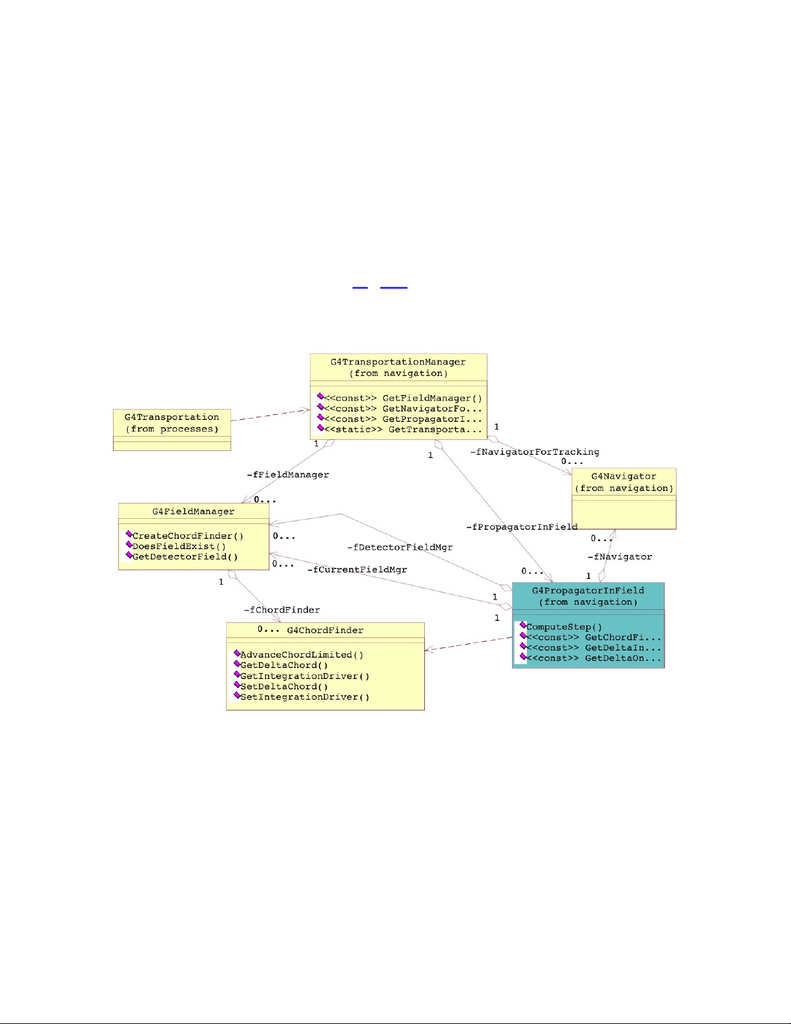

criterion. It also returns an Approximate point on the curve near to a

(chord) point. The G4ChordFinder handles all geometrical track

"advancements" in the field. The G4ChordFinder must be created

either by calling CreateChordFinder() for a Magnetic Field from

G4FieldManager or by the user creating a G4ChordFinder object

"manually" and setting the pointer.

The object-oriented design of the classes related to the electromagnetic field

is shown in the class diagram of Fig. 16. The diagram is described in UML

notation.

Fig. 16 Electromagnetic Field

Footnotes

[figure not shown]

Particles

Design Philosophy

The particles category implements the facilities necessary to describe the

physical properties of particles for the simulation of particle-matter

interactions. All particles are based on the G4ParticleDefinition class,

which describes basic properties such as mass, charge, etc., and also allows

the particle to carry a list of processes to which it is sensitive. A first-level

extension of this class defines the interface for particles that carry cuts

information, for example range cut versus energy cut equivalence. A set of

virtual, intermediate classes for leptons, bosons, mesons, baryons, etc.,

allows the implementation of concrete particle classes which define the

actual particle properties and, in particular, implement the actual range

versus energy cuts equivalence. All concrete particle classes are instantiated

as singletons to ensure that all physics processes refer to the same particle

properties.

Class Design

The object-oriented design of the 'particles' related classes is shown in the

following class diagrams. The diagrams are described in the Booch

notation. The Fig. 17 shows a general overview of the particle classes. Fig.

to the particle decay table in the G4ParticleDefinition. This decay table is

used by decay process and Fig. 21 shows the classes related to the decay

process and decay channels

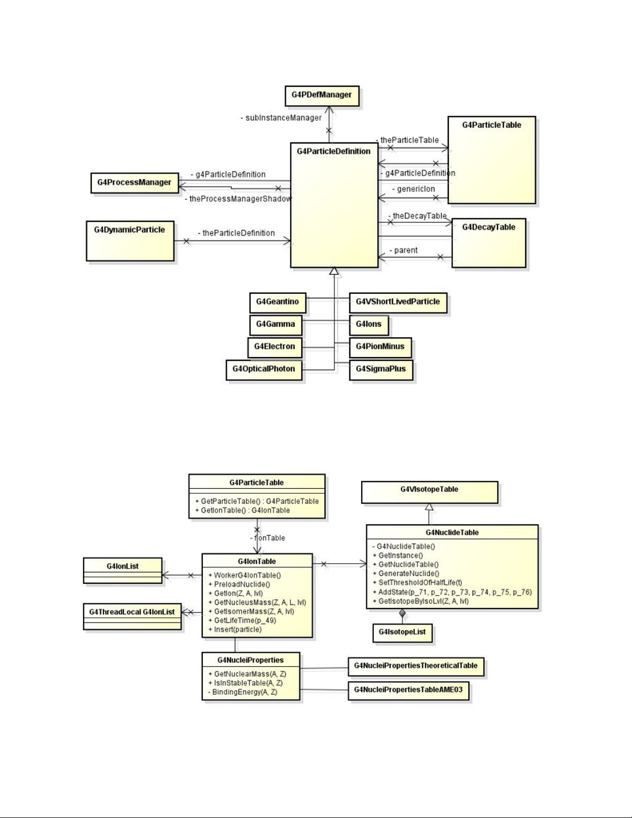

Fig. 17 Particle classes

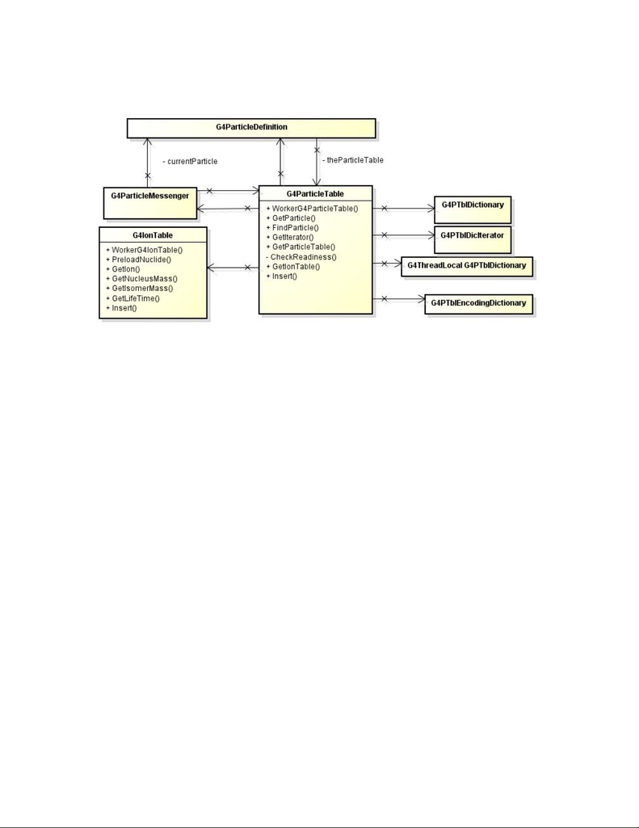

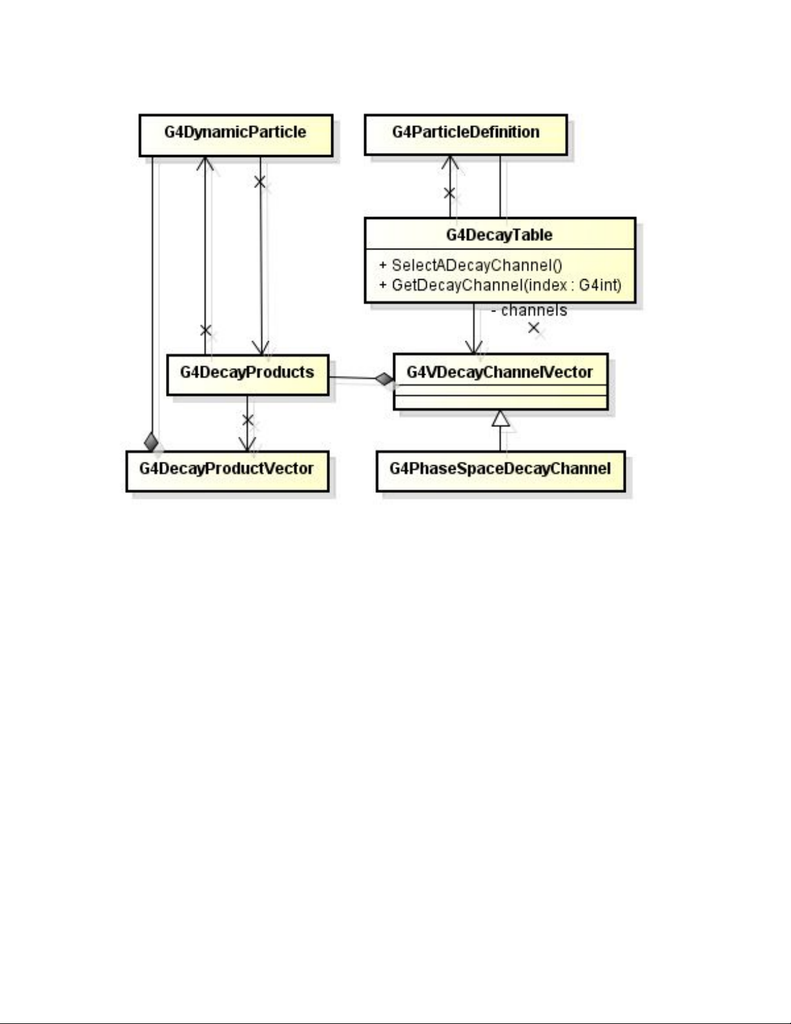

Fig. 20 Decay Table

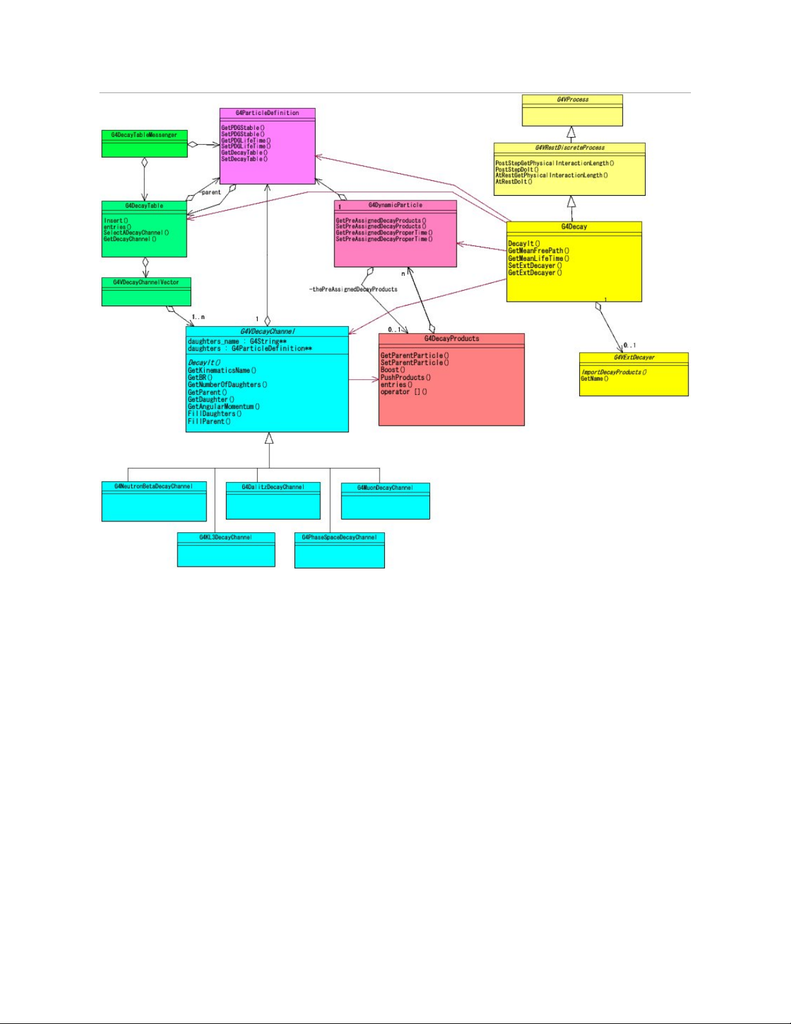

Fig. 21 Particle Decay

Footnotes

Materials

Design Philosophy

The design of the materials category reflects what exists in nature: materials

are made of a single element or a mixture of elements, and elements are

made of a single isotope or a mixture of isotopes.

Materials have been initially designed as amorphous, with properties

obtained by linear combinations of the properties of the elements or

isotopes building them, like radiation and interaction lengths, etc. Provision

was taken though to allow their ionisation parameters for departing from

this assumption with the ability to override the default calculations, like the

mean ionisation potential for example. Since Geant4 version 10.3, materials

have been extended to allow for crystalline and molecular structures to be

freely defined and associated with a material.

The materials category also defines optical surface properties used in the

tracking of optical photons.

Design

Classes For Material Description

The material description is based on three main classes:

G4Isotope:

used to define isotopes by name, atomic number Z and number of

nucleons N. The molar mass A can be specified, and is otherwise taken

from Geant4 NIST database. The isomer state can also be specified.

This class is essentially a "simple data container" and does not perform

any physics calculations.

[figure not shown]

G4Element:

defines elements as isotopes composition, with relative abundance. This

class also holds the atomic electron shell structure, that it retrieves for

itself using the G4AtomicShells utility class.

G4AtomicShells is a "database" class holding the atomic shells and

subshells, number of electrons in each and related binding energies, for

the first 100 elements.

Similarly, G4Element also retrieves the element ionisation data, using

the other utility and database class G4IonisParamElm.

The class computes derived quantities : Coulomb correction and Tsai

radiation length factors (Phys Rev. D50 3-1 (1994) page 1254). These

calculations are triggered in the constructor, or in the AddIsotope

method.

G4Material:

defines a material as a collection of elements -directly, or by mixture of

materials- adding, on top of the element composition, the physical

properties density, state, temperature, pressure.

A material has also ionisation properties, gathered in an

G4IonisParamMat object. The material creates this object, referencing

itself to this ionisation object. This one extract properties from the

element material composition. For the mean ionisation energy, it may

use values defined for chemical formulas, or deduce from the element

composition, or accept a value set directly.

When the composition of the material is changed (adding an element or

a material), derived quantities are computed, including radiation and

nuclear interaction lengths.

These three classes hold each a static vector holding all created objects of

the class.

The diagram of the these three main classes for material description

together with their utility classes is shown in the Fig. 22.

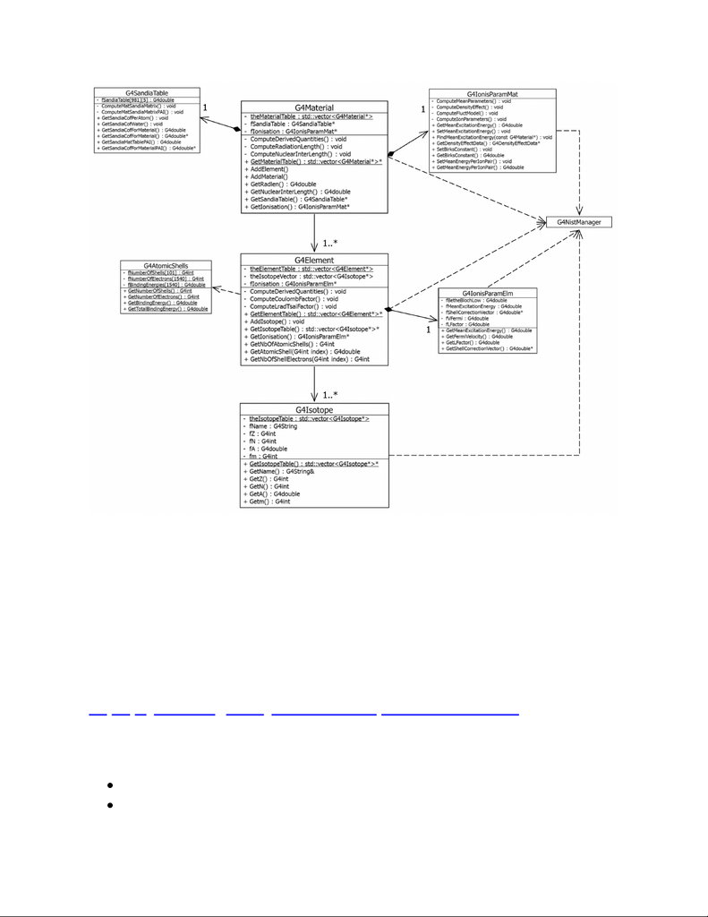

Fig. 22 The three main classes used for material description, together with

their utility classes.

The NIST Manager Utility

The G4NistManager utility singleton class provides elements and materials

construction according to the NIST database on Atomic Weights and

Isotope Compositions,

http://physics.nist.gov/PhysRefData/Compositions/index.html . The

G4NistManager is an interface class holding and steering one instance of the

following classes:

G4NistElementBuilder ,

G4NistMaterialBuilder ,

[figure not shown]

G4NistMessenger .

The G4NistElementBuilder and G4NistMaterialBuilder classes proceed

in a similar manner, with an initialisation phase in which known elements

and materials are essentially "registered" (under std::vector's of names,

properties, etc.) but without actual creation of the G4Element, G4Isotope

and G4Material objects. These creation happen on user's calls

FindOrBuildElement or FindOrBuildMaterial.

During the initialisation phase of these NIST builder objects, vectors of

elements and materials names and properties are hence created. They may

be used by the material construction classes exposed in the previous

section, which explains the dependencies on G4NistManager shown in the

figure.

Optical Classes

The classes for describing optical properties are:

G4SurfaceProperty: the base class for optical properties, which

consists essentially in the enumeration G4SurfaceType, and which

holds a static std::vector<G4SurfaceProperty*> of the properties

created, accessible by the static method GetSurfacePropertyTable() ,

G4OpticalSurface : which specialises G4SurfaceProperty, defining

the enumerations G4OpticalSurfaceFinish and

G4OpticalSurfaceModel (this is presented in details in the user's guide

for application developer),

G4MaterialPropertiesTable : which holds the various optical

properties as associations of a string key and a

G4PhysicsOrderedFreeVector; this key is used by the optical physics

processes to get the properties they need for the simulation.

Material Extension

Since Geant4 version 10.3, a material extension capability has been

introduced. The idea is to allow a material to get an arbitrary number of

extensions, freely defined, that specialized processes may consume for their

[figure not shown]

physics calculations. Examples of such extensions are crystal structures -for

channelling-, and molecular properties -for low energy processes-.

G4Material object. The class G4ExtendedMaterial class inherits from

G4Material, overriding IsExtended(), to make it responding "true". This

method is checked at tracking time by the specialised processes. The

constructors of G4ExtendedMaterial have the same signatures than the

ones of G4Material.

The extended properties (e.g.: crystal structure, molecular properties) are to

be implemented in concrete classes inheriting from the interface class

G4VMaterialExtension. A G4ExtendedMaterial object can hold an

arbitrary number of G4VMaterialExtension pointers, managed by a hash

map. Each G4VMaterialExtension concrete class object is associated to a

string key, that is used to retrieve the object.

The diagram showing the relation between these three classes is shown in

Fig. 23.

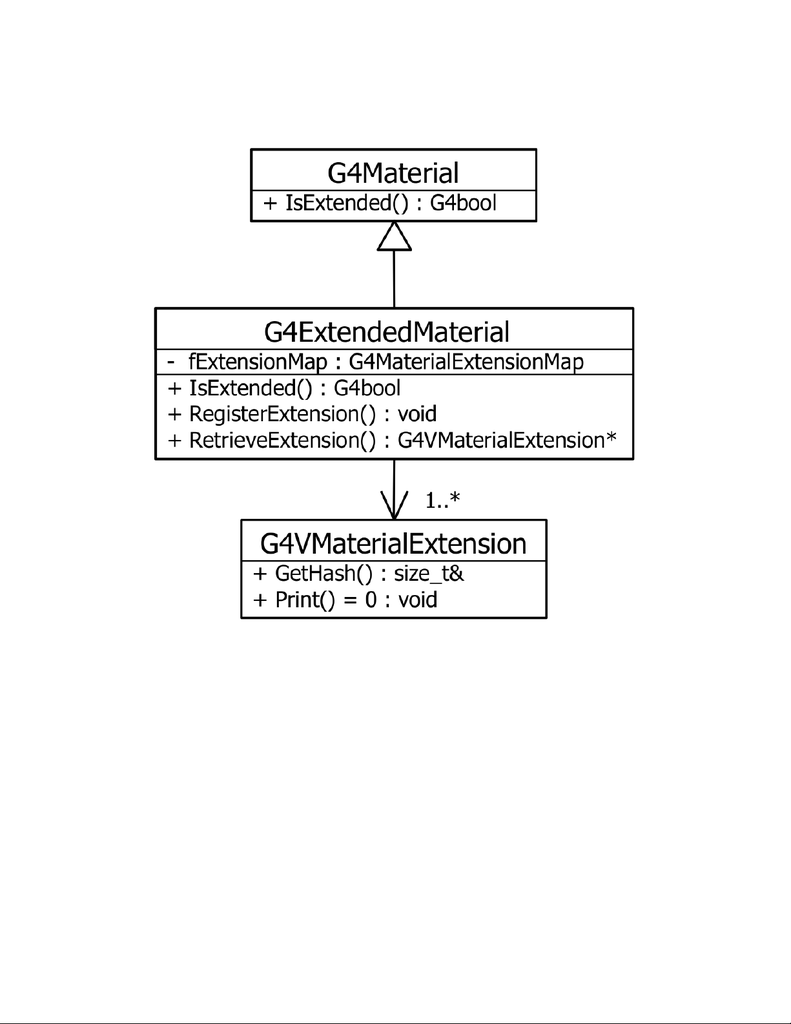

Fig. 23 Classes involved in material extension capability.

The first concrete implementation of G4VMaterialExtension is

G4CrystalExtension.

Footnotes

[figure not shown]

Global Usage

Design Philosophy

The global category covers the system of units, constants, numerics and

random number handling. It can be considered a place-holder for "general

purpose" classes used by all categories defined in Geant4. No back-

dependencies to other Geant4 categories affect the "global" domain. There

are direct dependencies of the global category on external packages, such as

CLHEP, STL, and miscellaneous system utilities.

Within the management sub-category are "utility" classes generally used

within the Geant4 kernel. They are, for the most part, uncorrelated with one

another and include:

G4Allocator

G4FastVector

G4ReferenceCountedHandle

G4PhysicsVector, G4LPhysicsFreeVector,

G4PhysicsOrderedFreeVector

G4Timer

G4UserLimits

G4UnitsTable

A general description of these classes is given in section 3.2 of the Geant4

User's Guide for Application Developers.

The module includes wrappers to most CLHEP classes used in Geant4, and

tools for memory management (G4Cache, G4AutoDelete) and for threading

(G4AutoLock, G4Threading, G4ThreadLocalSingleton,

G4TWorkspacePool). It also provides specialised fast implementations for

some heavily used mathematical functions, like G4Exp, G4Log, G4Pow.

In applications where it is necessary to generate random numbers (normally

from the same engine) in many different methods and parts of the program,

[figure not shown]

it is highly desirable not to rely on or require knowledge of the global

objects instantiated. By using static methods via a unique generator, the

randomness of a sequence of numbers is best assured. Hence the use of a

static generator has been introduced in the original design of HEPRandom

as a project requirement in Geant4.

Class Design

Analysis and design of the HEPRandom module have been achieved

following the Booch Object-Oriented methodology. Some of the original

design diagrams in Booch notation are reported below. The figure is a

general picture of the static class diagram.

HepRandomEngine - abstract class defining the interface for each

Random engine. Its pure virtual methods must be defined by its

subclasses representing the concrete Random engines.

HepJamesRandom - class inheriting from HepRandomEngine and

defining a flat random number generator according to the algorithm

described in "F.James, Comp.Phys.Comm. 60 (1990) 329".

DRand48Engine - class inheriting from HepRandomEngine and

defining a flat random number generator according to the drand48()

and srand48() system functions from the C standard library.

RandEngine - class inheriting from HepRandomEngine and defining

a flat random number generator according to the rand() and srand()

system functions from the C standard library.

RanluxEngine - class inheriting from HepRandomEngine and

defining a flat random number generator according to the algorithm

described in "F.James, Comp.Phys.Comm. 60 (1990) 329-344" and

originally implemented in FORTRAN 77 as part of the MATHLIB

HEP library. It provides 5 different "luxury" levels [0..4].

RanecuEngine - class inheriting from HepRandomEngine and

defining a flat random number generator according to the algorithm

RANECU originally written in FORTRAN 77 as part of the

MATHLIB HEP library. It uses a table of seeds which provides

uncorrelated couples of seed values.

MixMaxRng - class inheriting from HepRandomEngine and

interfacing the MixMax Matrix PseudoRandom Number Generator

[figure not shown]

described in J.Comput.Phys. 97, 573 (1991). This class is instantiated

by default as the default random engine.

HepRandom - the main class collecting all the methods defining the

different random generators applied to HepRandomEngine. It is a

singleton class which all the distribution classes derive from. This

singleton is instantiated by default.

RandFlat - distribution class for flat random number generation. It

also provides methods to fill an array of flat random values, given its

size or shoot bits.

RandExponential - distribution class defining exponential random

number distribution, given a mean. It also provides a method to fill an

array of flat random values, given its size.

RandGauss - distribution class defining Gauss random number

distribution, given a mean or specifying also a deviation. It also

provides a method to fill an array of flat random values, given its size.

RandBreitWigner - distribution class defining the Breit-Wigner

random number distribution. It also provides a method to fill an array

of flat random values, given its size.

RandPoisson - distribution class defining Poisson random number

distribution, given a mean. It also provides a method to fill an array of

flat random values, given its size.

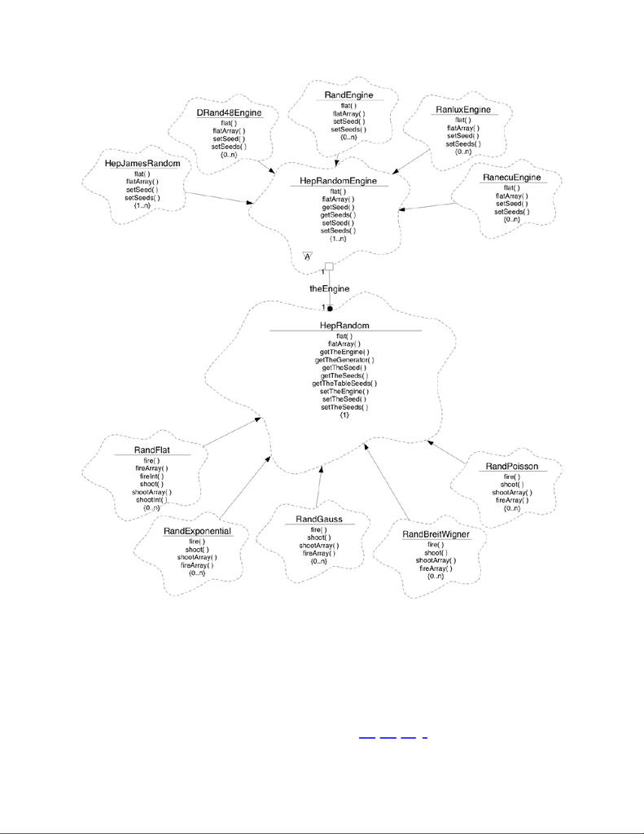

Fig. 24 HEPRandom module

For detailed documentation about the HEPRandom classes see the CLHEP

documentation <http://proj-clhep.web.cern.ch/proj-clhep/#docu>.

Information written in this manual is extracted from the original manifesto

distributed with the HEPRandom package <http://proj-

[figure not shown]

clhep.web.cern.ch/proj-

clhep/doc/CLHEP_1_7/UserGuide/Random/Random.html>`__.

HEPNumerics

The HEPNumerics module includes a set of classes which implement

numerical algorithms for general use in Geant4. The User's Guide for

Application Developers contains a description of each class. Most of the

algorithms were implemented using methods from the following books:

B.H. Flowers, "An introduction to Numerical Methods In C++",

Clarendon Press, Oxford 1995.

M. Abramowitz, I. Stegun, "Handbook of mathematical functions",

DOVER Publications INC, New York 1965; chapters 9, 10, and 22.

The HEPNumerics module provides general mathematical methods

supporting Geant4 Monte-Carlo simulation processes. Among these, there

are methods for function and array interpolations using known special

functions, class method integration solving polynomial equation (up to 4th

order) and some others.

Of particular interest is the templated class G4Integrator which consists of

methods allowing to integrate class methods. Since the type whose method

should be integrated is not known in advance, G4Integrator uses templated

signatures and pointers to functions in its API. It provides both usual

numerical methods like adaptive Gauss or Simpson integration, and more

sophisticated (faster and at the same accurate) methods based on the

orthogonal polynomials.

Among the different integration methods involving orthogonal polynomials

there are: Gauss-Legendre, Gauss-Chebyshev, Gauss-Hermite and Gauss-

Jacobi methods:

template <class T, class F>

G4double G4Integrator<T,F>::Legendre( T& typeT, F f, G4double

a,

G4double b, G4int nLegendre

)

[figure not shown]

//

// The value nLegendre set the accuracy required, i.e the

number of points

// where the function pFunction will be evaluated during

integration.

// The function creates the arrays for abscissas and weights

that used

// in Gauss-Legendre quadrature method.

// The values a and b are the limits of integration of the

function f.

// nLegendre MUST BE EVEN !!!

// Returns the integral of the function f between a and b, by

2*fNumber point

// Gauss-Legendre integration: the function is evaluated

exactly

// 2*fNumber times at interior points in the range of

integration.

// Since the weights and abscissas are, in this case, symmetric

around

// the midpoint of the range of integration, there are actually

only

// fNumber distinct values of each.

// Convenient for using with some class object dataT

template <class T, class F>

G4double G4Integrator<T,F>::Legendre10( T& typeT, F f,G4double

a,

G4double b )

//

// Returns the integral of the function to be pointed by T::f

between a and b,

// by ten point Gauss-Legendre integration: the function is

evaluated exactly

// ten times at interior points in the range of integration.

Since the weights

// and abscissas are, in this case, symmetric around the

midpoint of the

// range of integration, there are actually only five distinct

values of each

// Convenient for using with class object typeT. The method is

very fast and accurate enough.

// Roots and weights are from Abramowitz M., Stegun I.A. 1964 ,

Handbook of Math... , p. 916

[figure not shown]

template <class T, class F>

G4double G4Integrator<T,F>::Legendre96( T& typeT, F f,G4double

a,

G4double b )

//

// Returns the integral of the function to be pointed by T::f

between a and b,

// by 96 point Gauss-Legendre integration: the function is

evaluated exactly

// ten Times at interior points in the range of integration.

Since the weights

// and abscissas are, in this case, symmetric around the

midpoint of the

// range of integration, there are actually only five distinct

values of each

// Convenient for using with some class object typeT. The

method is very accurate and fast enough.

// Roots and weights are from Abramowitz M., Stegun I.A. 1964 ,

Handbook of Math... , p. 919

template <class T, class F>

G4double G4Integrator<T,F>::Chebyshev( T& typeT, F f, G4double

a,

G4double b, G4int

nChebyshev )

//

// Integrates function pointed by T::f from a to b by Gauss-

Chebyshev

// quadrature method.

// Convenient for using with class object typeT

template <class T, class F>

G4double G4Integrator<T,F>::Laguerre( T& typeT, F f, G4double

alpha,

G4int nLaguerre )

//

// Integral from zero to infinity of

std::pow(x,alpha)*std::exp(-x)*f(x).

// The value of nLaguerre sets the accuracy.

// The function creates arrays fAbscissa[0,..,nLaguerre-1] and

// fWeight[0,..,nLaguerre-1] .

// Convenient for using with class object 'typeT' and

[figure not shown]

[#1]

Footnotes

http://proj-clhep.web.cern.ch/proj-clhep/

(typeT.*f) function

// (T::f)

template <class T, class F>

G4double G4Integrator<T,F>::Hermite( T& typeT, F f, G4int

nHermite )

//

// Gauss-Hermite method for integration of std::exp(-x*x)*f(x)

// from minus infinity to plus infinity.

template <class T, class F>

G4double G4Integrator<T,F>::Jacobi( T& typeT, F f, G4double

alpha,

G4double beta, G4int

nJacobi )

//

// Gauss-Jacobi method for integration of ((1-x)^alpha)*

((1+x)^beta)*f(x)

// from minus unit to plus unit (-1,+1).

[figure not shown]

Design of Visualisation Category

Design Philosophy

The visualisation category consists of the classes required to display

detector geometry, particle trajectories, tracking steps, and hits. It also

provides visualisation drivers, which are interfaces to external graphics

systems.

A wide variety of user requirements went into the design of the

visualisation category, for example:

very quick response in surveying successive events,

high-quality output for presentation and documentation,

flexible camera control for debugging detector geometry and physics,

selection of visualisable objects,

interactive picking of graphical objects for attribute editing or

feedback to the associated data,

highlighting incorrect intersections of physical volumes,

co-working with graphical user interfaces.

Because it is very difficult to respond to all of these requirements with only

one built-in visualiser, an abstract interface was developed which supports

several complementary graphics systems. Here the term graphics system

means either an application running as a process independent of Geant4 or a

graphics library to be compiled with Geant4. A concrete implementation of

the interface is called a visualisation driver, which can use a graphics

library directly, communicate with an independent process via pipe or

socket, or simply write an intermediate file for a separate viewer.

The Graphics Interfaces

G4VVisManager:

[figure not shown]

All user code writes to the graphics systems through this pure abstract

interface. It contains Draw methods for all the graphics primitives in the

graphics_reps category (G4Polyline, G4Circle, etc.), geometry objects

(through their base classes, G4VSolid, G4PhysicalVolume and

G4LogicalVolume) and hits and trajectories (through their base classes,

G4VHit and G4VTrajectory).

Since this is an abstract interface, all user code must check that there

exists a concrete instantiation of it. A static method is provided, so a

typical user code fragment is:

Note that this allows the building an application without a concrete

implementation, for example for a batch job, even if some code, like the

above, is still included.

The concrete implementation of this interface is hereafter referred to as

the visualisation manager.

G4VGraphicsScene:

The visualisation manager must also provide a concrete implementation

of the subsidiary interface, G4VGraphicsScene. It is only for use by the

kernel and the modelling category. It offers direct access to a "scene

handler" through a reference provided by the visualisation manager. It is

described in more detail in the section on extending the toolkit

functionality.

The Geant4 distribution includes implementations of the above interfaces,

namely G4VisManager and G4VSceneHandler respectively, and their

associated classes. These define further abstract base classes for

visualisation drivers. Together they form the |Geant4| Visualisation

System. A variety of concrete visualisation drivers are also included in the

distribution. Details of how to implement a visualisation driver are given in

Visualisation. Of course, it is always possible for a user to implement his or

G4VVisManager::GetConcreteInstance();

if(pVVisManager) {

pVVisManager->Draw(G4Circle...

...

[figure not shown]

her own concrete implementations of G4VVisManager and

G4VGraphicsScene replacing the Geant4 Visualisation System altogether.

The Geant4 Visualisation System

The Geant4 Visualisation System consists of

G4VisManager: An implementation of the G4VVisManager interface.

It manages multiple graphics systems and defines three more concepts

-- the scene (G4Scene), the scene handler (base class

G4VSceneHandler, itself a sub-class of G4VGraphicsScene) and the

viewer (base class G4VViewer) -- see below. G4VisManager is a

singleton and an abstract class, requiring the user to derive from it a

concrete visualisation manager (G4VisExecutive is provided -- see

below). Roles and structure of the visualisation manager are described

in Chapter 8 of the User's Guide for Application Developers.

G4VisExecutive: A concrete visualisation manager that implements

the virtual functions RegisterGraphicsSystems and

RegisterModelFactories. These functions must be in the users' domain,

since the graphics systems and models that are instantiated by them

are, in many cases, provided by the user (graphics libraries, etc.). It is

therefore implemented as a .hh-.icc combination that is designed to be

included in the users' code. Of course, the user may write his or her

own.

G4Scene The scene is a list if models for physical volumes, axes, hits,

trajectories, etc. - see Modelling sub-category. They are distinguished

according to their lifetime -- "run-duration" for physical volumes, etc.,

"end-of-event" for hits and trajectories, etc. The end-of-event models

are only to be used when the Geant4 state indicates the end of event

has been reached. The scene has an extent (G4VisExtent), which is

updated by the scene when a new model is added (each model itself

has an extent), and a "standard" target point; these are used to define

the standard view -- see below. In addition, the scene keeps flags

which indicate whether end-of-event objects should be accumulated or

refreshed for each event or run.

[figure not shown]

G4VGraphicsSystem: This is an abstract base class for scene handler

and viewer factories. It is used by the visualisation manager to create

scene handlers and viewers on request.

G4VSceneHandler: A sub-class of G4VGraphicsScene, itself an

abstract base class for specific scene handlers, whose job is to convert

the scene into graphics-system-specific code for the viewer. For

example, the scene handler may create a graphical database, taking

care to separate run-duration (persistent) and end-of-event (transient)

information (this is described further in Dealing with transient objects

G4VViewer: An abstract base class for specific viewers. Its job is to

create windows or files and identify where and how the final view

should be rendered. It has view parameters (G4ViewParameters)

which specify viewpoint direction, type of rendering (wireframe or

surface), etc. It is the view's responsibility, noting the scene's extent

and target point, to choose a camera position and magnification that

ensures that the scene is automatically and comfortably rendered in the

viewing window. This is then the standard view, and any further

operations requested by the user - zoom, pan, etc. - are relative to this

standard view. The class G4ViewParameters has utility routines to

assist this procedure; it is strongly advised that toolkit developers

writing a viewer should study the G4ViewParameters class, whose

header file contains much useful information (also preserved in the

Software Reference Manual).

The viewer is messaged by the vis manager when the user issues

commands, such as /vis/viewer/refresh. This invokes methods such

as SetView, ClearView and DrawView. A detailed description of the

call sequences is given in sections Important Command Actions to

What happens in ProcessScene?.

Note there is no restriction on the number or type of scene handlers or

viewers. There may be several scene handlers processing the same or

different scenes, each with several viewers (for example, the same scene

from differing viewpoints).

By defining a set of three C++ classes inheriting from the virtual base

classes - G4VGraphicsSystem, G4VSceneHandler and G4VViewer - an

arbitrary graphics system can easily be plugged in to Geant4. The plugged-

in graphics system is then available for visualising detector simulations.

Together, this set of three concrete classes is called a "visualisation driver".

The DAWN-File driver, for example, is the interface to the Fukui Renderer

DAWN, and is implemented by the following set of classes:

1. G4DAWNFILE : public G4VGraphicsSystem for creation of the scene

handlers and viewers

2. G4DAWNFILESceneHandler : public G4VSceneHandler for

modelling 3D scenes

3. G4DAWNFILEView : public G4VView for rendering 3D scenes

Several visualisation drivers are distributed with Geant4. They are

complementary to each other in many aspects. For details, see Chapter 8 of

the User's Guide for Application Developers.

Modelling sub-category

G4VModel

a base class for visualisation models. A model is a graphics-system-

independent description of a Geant4 component.

The sub-category visualization/modeling defines how to model a 3D

scene for visualisation. The term "3D scene" indicates a set of

visualisable component objects put in a 3D world. A concrete class

inheriting from the abstract base class G4VModel defines a "model",

which describes how to visualise the corresponding component object

belonging to a 3D scene. G4ModelingParameters defines various

associated parameters.

For example, G4PhysicalVolumeModel knows how to visualise a

physical volume. It describes a physical volume and its daughters to any

desired depth. G4HitsModel knows how to visualise hits.

G4TrajectoriesModel knows how to visualise trajectories.

[figure not shown]

The main task of a model is to describe itself to a 3D scene by giving a

concrete implementation of the following virtual method of G4VModel:

The argument class G4VGraphicsScene is a minimal abstract interface

of a 3D scene for the Geant4 kernel defined in the graphics_reps

category. Since G4VSceneHandler and its concrete descendants inherit

from G4VGraphicsScene, the method DescribeYourselfTo() can pass

information of a 3D scene to a visualisation driver.

It is easy for a toolkit developer of Geant4 to add a new kind of

visualisable component object. It is done by implementing a new class

inheriting from G4VModel.

G4VTrajectoryModel

an abstract base class for trajectory drawing models.

A trajectory model governs how an individual trajectory is drawn.

Concrete models inheriting from G4VTrajectoryModel must implement

two pure virtual functions:

See for example G4TrajectoryDrawByParticleID.

G4VModelFactory

an abstract base class for factories creating models and associated

messengers.

It is not necessary to generate messengers for a trajectory model that

will be constructed and configured directly in compiled code. If the user

requires model creation and configuration features through interactive

commands, however, there must be a mechanism to generate both

models and their associated messengers. This is the role of

G4VModelFactory. Concrete factories inheriting from

G4VModelFactory are responsible for creating a concrete model and

virtual void Draw(const G4VTrajectory&, G4int i_mode = 0)

const = 0;

virtual void Print(std::ostream& ostr) const = 0;

[figure not shown]

concrete messengers. To help ensure a type safe messenger to model

interaction on the command line, the messengers should inherit from

G4VModelCommand.

Concrete factories must implement one pure virtual function:

where placement indicates which directory space the commands should

occupy. See for example G4TrajectoryDrawByParticleIDFactory.

View parameters

View parameters such as camera parameters, drawing styles

(wireframe/surface etc) are held by G4ViewParameters. Each viewer holds

a view parameters object which can be changed interactively and a default

object (for use in the /vis/viewer/reset command).

If a toolkit developer of Geant4 wants to add entries of view parameters, he

should add fields and methods to G4ViewParameters. Detailed instructions

are given in Visualisation under Extending Toolkit Functionality.

Visualisation Attributes

All drawable objects (should) have a method:

A drawable object might be:

a "visible" (i.e., inheriting G4Visible), such as a polyhedron, polyline,

circle, etc. (note that text is a slightly special case - see below) or

a solid whose vis attributes are held in its logical volume.

Finding the applicable vis attributes

Create(const G4String& placement, const G4String& modelName)

= 0;

const G4VisAttributes* GetVisAttributes() const;

[figure not shown]

This is an issue for all scene handlers. The scene handler is where the

colour, style, auxiliary edge visibility, marker size, etc., of individual

drawable objects are needed.

Visibles

If the vis attributes pointer is zero, drivers should pick up the default vis

attributes from the viewer:

where visible denotes any visible object (polyhedron, circle, etc.).

There is a utility function G4VViewer::GetApplicableVisAttributes which

does this, so an alternative is:

Confusingly, there is a utility function G4VSceneHandler::GetColour which

also does this, so if it's only colour you need, the following suffices:

but equally well:

or even:

const G4VisAttributes* pVisAtts = visible.GetVisAttributes();

if (!pVisAtts)

pVisAtts = fpViewer-

>GetViewParameters().GetDefaultVisAttributes();

const G4VisAttributes* pVisAtts =

fpViewer-

>GetApplicableVisAttributes(visible.GetVisAttributes());

const G4Colour& colour GetColour(visible);

const G4VisAttributes* pVisAtts =

fpViewer-

>GetApplicableVisAttributes(visible.GetVisAttributes());

const G4Colour& colour pVisAtts->GetColour();

const G4VisAttributes* pVisAtts = visible.GetVisAttributes();

if (!pVisAtts)

pVisAtts = fpViewer-

[figure not shown]

Text

Text is a special case because it has its own default vis attributes:

and there is a utility function G4VSceneHandler::GetTextColour:

Solids

For specific solids, the G4PhysicalVolumeModel that provides the solids

also provides, via PreAddSolid, a pointer to its vis attributes. If the vis

attributes pointer in the logical volume is zero, it provides a pointer to the

default vis attributes in the model, which in turn is (currently) provided by

the viewer's vis attributes (see

G4VSceneHandler::CreateModelingParameters). So the vis attributes

pointer is guaranteed to be pertinent.

If the concrete driver does not implement AddSolid for any particular solid,

the base class converts it to primitives (usually a G4Polyhedron) and again,

the vis attributes pointer is guaranteed.

Drawing style

The drawing style is normally determined by the view parameters but for

individual drawable objects it may be overridden by the forced drawing

style flags in the vis attributes. A utility function

G4ViewParameters::DrawingStyle G4VSceneHandler::GetDrawingStyle is

provided:

>GetViewParameters().GetDefaultVisAttributes();

const G4Colour& colour pVisAtts->GetColour();

const G4VisAttributes* pVisAtts = text.GetVisAttributes();

if (!pVisAtts)

pVisAtts = fpViewer-

>GetViewParameters().GetDefaultTextVisAttributes();

const G4Colour& colour pVisAtts->GetColour();

const G4Colour& colour GetTextColour(text);

[figure not shown]

Auxiliary edges

Similarly, the visibility of auxiliary/soft edges is normally determined by

the view parameters but may be overridden by the forced auxiliary edge

visible flag in the vis attributes. Again, a utility function

G4VSceneHandler::GetAuxEdgeVisible is provided:

LineSegmentsPerCircle

Also, the precision of rendering curved edges in the polyhedral

representation of volumes is normally determined by the view parameters

but may be overridden by a forced attribute. A utility function that respects

this, G4VSceneHandler::GetNoOfSides, is provided. For example:

Marker size

These have nothing to do with vis attributes; they are an extra property of

markers, i.e., objects that inherit G4VMarker (circles, squares, text, etc.).

However, the algorithm for the actual size is quite complicated and a utility

function G4VSceneHandler::GetMarkerSize is provided:

sizeType is world or screen, signifying that the size is in world coordinates

or screen coordinates respectively.

Footnotes

G4ViewParameters::DrawingStyle drawing_style =

GetDrawingStyle(pVisAtts);

G4bool isAuxEdgeVisible = GetAuxEdgeVisible (pVisAtts);

G4Polyhedron::SetNumberOfRotationSteps (GetNoOfSides

(pVisAttribs));

MarkerSizeType sizeType;

G4double size = GetMarkerSize (text, sizeType);

[figure not shown]

Intercoms

Design Philosophy

The intercoms category implements an expandable command interpreter

which is the key mechanism in Geant4 for realising customizable and state-

dependent user interactions with all categories without being perturbed by

the dependencies among classes. The capturing of commands is handled by

a C++ abstract class G4UIsession. Various concrete implementations of the

command capturer are contained in the [user] interfaces category. Taking

into account the rapid evolution of graphical user interface (GUI)

technology and consequent dependence on external facilities, plural and

extensible GUIs are offered.

Programmers need only know how to register the commands and

parameters appropriate to their problem domain; no knowledge of GUI

programming is required to allow an application to use them through one of

the available GUIs.

The intercoms category also provides the virtual base classes

G4VVisManager,

G4VGraphicsScene, and

G4VGlobalFastSimulationManager.

Class Design

G4UISession -

G4UIBatch -

G4UICommand -

G4UIparameter -

G4UImessenger -

G4UIExecutive: A concrete interface manager. It will register the UI

selected by the environment variable set. It will take first by default the

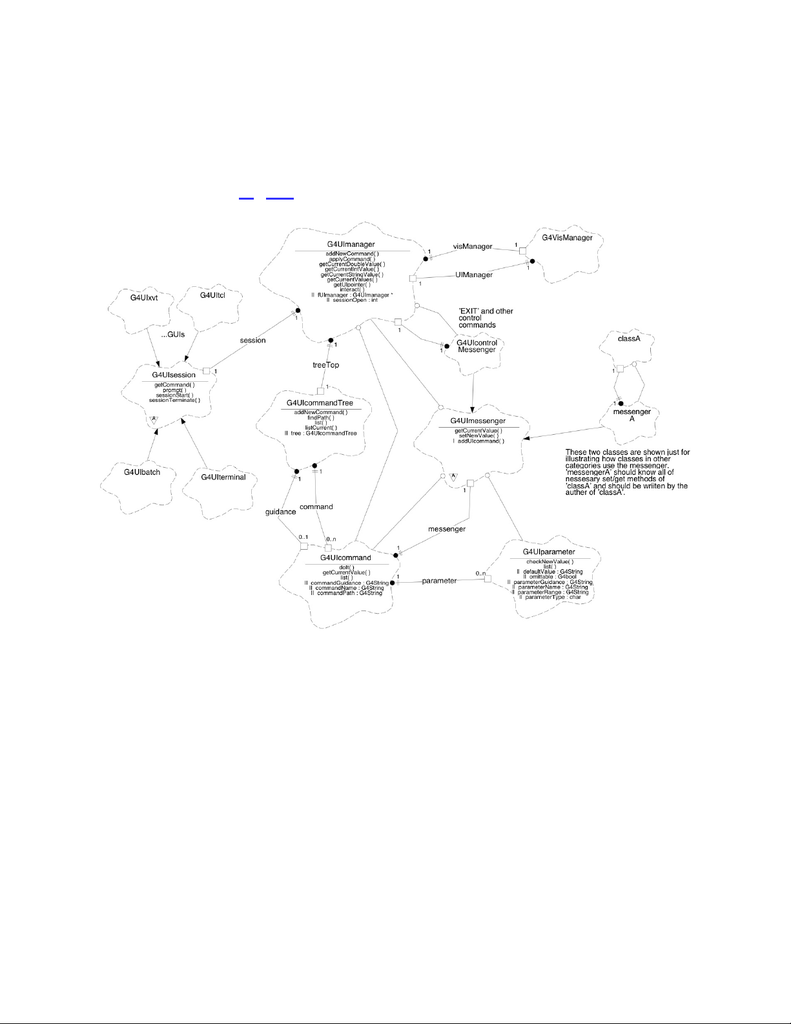

following order : G4UI_USE_QT, G4UI_USE_XM,

G4UI_USE_WIN32, G4UI_USE_TCSH, Terminal

The object-oriented design of the 'user interface' related classes is shown in

the class diagram Fig. 25. The diagram is described in the Booch notation.

Fig. 25 Overview of intercom classes

Footnotes

[figure not shown]

Parallelism in Geant4: multi-

threading capabilities

Event level parallelism

Geant4 event-level parallelism is based on a master-worker model in which

a set of threads (the workers) are spawned and are responsible for the

simulation of events, while the steering and control of the simulation is

given to an additional entity (the master).

Multi-threading functionalities are implemented with new classes or

modifications of existing classes in the run category:

The new run-manager class G4MTRunManager (that inherits from

G4RunManager) implements the master model. It uses the mandatory

class G4MTRunManagerKernel, a multi-threaded equivalent of

G4RunManagerKernel

The new run-manager class G4WorkerRunManager (that inherits

from G4RunManager) implements the worker model. It uses the

mandatory class G4WorkerRunManagerKernel, the worker

equivalent of G4RunManagerKernel

The new user-initialisation class G4VUserActionInitialization is

responsible for the instantiating of thread-local user actions

The new user-initialisation class G4UserWorkerInitialization is

responsible for the initialisation of worker threads

Additional information on Geant4 multi-threading model can be found in

the section General Design.

In this chapter, after a brief reminder of basic design choices, we will

concentrate on aspects that are important for kernel developers, particularly

the most critical aspects for multi-threading in Geant4: memory handling,

split-classes and thread-local storage. In the following it is assumed that the

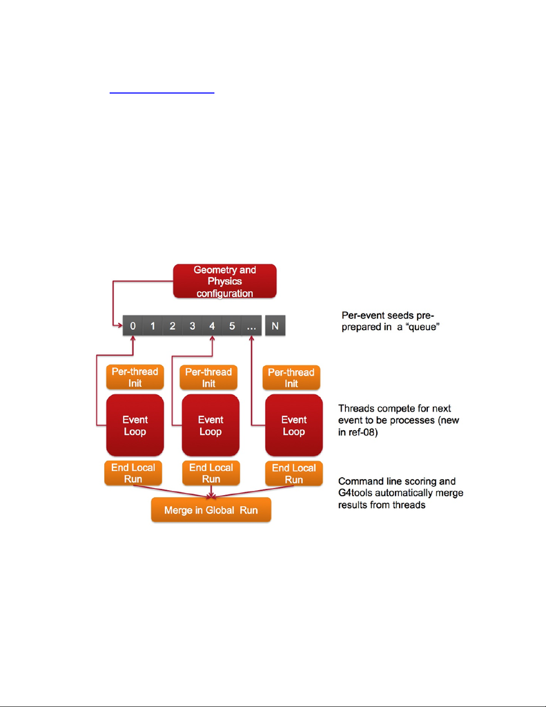

user is already familiar with the general aspects of multi-threading. The

section Additional material provides more information on this topic.

General Design

Geant4 Version 10.0 introduces parallelism at the event level: events are

tracked concurrently by independent threads. The parallelism model is

master-worker in which one or more threads are responsible of performing

the simulation, while a separate control flow controls and steers the work. A

diagram of the general overview of a multi-threaded Geant4 application is

shown here:

Fig. 26 Simplified schema of the master-worker model employed in Geant4

The user interacts with the master which is responsible for creating and

controlling worker threads. Before the simulation is started per-event seeds

are generated by the master. This operation guarantees reproducibility. Once

threads are spawned and configured, each worker is responsible for creating

a new G4Run and for simulating a subset of the events. At the end of the

run the results from each run are merged into the global run. Details on how

to interact with a multi-threaded simulation are discussed in the Guide for

Application Developers.

Geant4 parallelization makes use of the POSIX standard. The use of this

standard in Geant4 guarantees maximum portability between systems and

integration with advanced parallelization frameworks (for example we have

verified that this model co-works with TBB and MPI).

To effectively reduce the memory consumption in a multi-threaded

application, workers share instances of objects that consume the majority of

memory (geometry and physics tables); workers own thread-private

instances of the other classes (e.g. SensitiveDetectors, hits, etc). This choice

allowed the design of a lock-free code (i.e. no use of mutex during the event

loop), which guarantees maximum scalability (cfr: Euro-Par2010, Part II

LNCS6272, pp.287-303). Thread safety is obtained via Thread Local

Storage.

Similar to the sequential version of Geant4, master and workers are

represented by instances of classes inheriting from G4RunManager: the

G4MTRunManager class represents the master model, while

G4WorkerRunManager instances represent worker models. The user is

responsible for instantiating a single G4MTRunManager (or derived user-

class) instance. This class will instantiate and control one or more

G4WorkerRunManager instances. Users should never instantiate directly

an instance of the G4WorkerRunManager class.

A simplified class-diagram of the relevant classes for multi-threading and

their relationship is shown here:

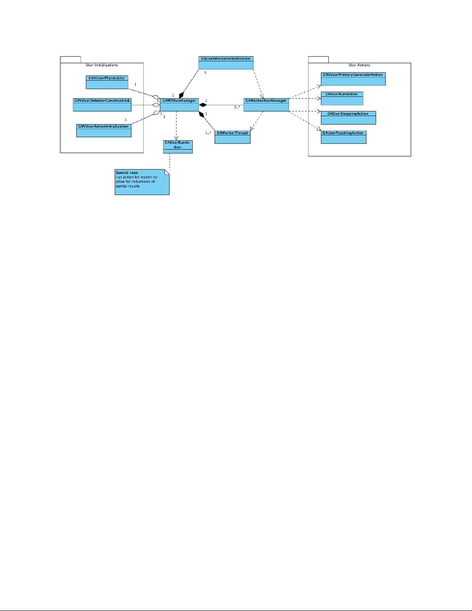

Fig. 27 Relevant classes and their interaction for multi-threaded

applications

As in sequential Geant4 users interact with the Geant4 kernel via user

initialisations and user actions. User initialisations

(G4VUserDetectorConstruction, GVUserPhysicsList and the new

G4VUserActionInitializtion) instances are shared among all threads (as

such they are registered to the G4MTRunManager instance); while user

actions (G4VUserPrimaryGeneratorAction, G4UserRunAction,

G4UserSteppingAction and G4UserTrackingAction) are not shared and a

separate instance exists for each thread. Since the master does not perform

simulation of events user actions do not have functions for

G4MTRunManager and should not be assigned to it. G4RunAction is the

exception to this rule since it can be attached to the master

G4MTRunManager to allow for merging of partial results produced by

workers.

Memory handling in Geant4 Version 10.0

Introduction

In Geant4 we distinguish two broad types of classes: ones whose instances

are separate for each thread (such as a physics process, which has a state),

and ones whose instances are shared between threads (e.g. an element

G4Element which holds constant data).

[figure not shown]

A few cases classes exist which have mixed behaviour - part of their state is

constant, and part is per-worker. A simple example of this is a particle

definition, such as G4Electron, which holds both data (which is constant)

and a pointer to the G4ProcessManager object for electrons - which must

be different for each worker (thread).

We handle these 'split' classes specially, to enable data members and

methods which correspond to the per-thread state to give a different result

on each worker thread. The implementation of this requires an array for

each worker (thread) and an additional indirection - which imposes a cost

each time the method is called. However this overhead is small and has

been measured to be about 1%. In this section we will discuss the details of

how we achieve thread-safety for different use-cases. The information

contained here is of particular relevance for toolkit developers that need to

adapt code to multi-threading to increase performances (typically to reduce

the memory footprint of an application sharing between threads' memory

consuming objects). It is however of general interest to understand some of

the more delicate aspects of multi-threading.

Thread safety and sharing of objects

To better understand how memory is handled and what are the issues

introduced by multi-threading it is easier to proceed with a simplified

example.

Let us consider the simplest possible class G4Class that consists of a single

data member:

Our goal is to transform the code of G4Class to make it thread-safe. A class

(or better, a method of a class) is thread-safe if more than one thread can

simultaneously operate on the class data member or its methods without

interfering with each other in an unpredictable way. For example if two

threads concurrently write and read the value of the data field fValue and

this data field is shared among threads, the two threads can interfere with

class G4Class {

[static] G4double fValue; //static keyword is optional

};

[figure not shown]

each other if no special code to synchronise the thread is added. This

condition is called data-race and is particularly dangerous and difficult to

debug.

A classical way to solve the data-race problem is to protect the critical

section of the code and the concurrent access to a shared memory location

using a lock or a mutex (see section Threading model utilities and

functions). However this technique can reduce overall performance because

only one thread at a time is allowed to be executed. It is important to reduce

to a minimum the use of locks and mutexes, especially in the event loop. In

Geant4 we have achieved thread-safety via the use of thread local storage.

This allows for virtually lock-free code at the price of an increased memory

footprint and a small CPU penalty. Explanations of thread-local storage are

provided by several external resources. For a very simple introduction, but

adequate for our discussion, web resources give sufficient detail (e.g.

wikipedia[#1]).

Before going into the details of how to use the thread-local storage

mechanism we need to introduce some terminology.

We define an instance of a variable to be thread-local (or thread-private) if

each thread owns a copy of the variable. A thread-shared variable, on the

contrary, is an instance of a variable that is shared among the threads (i.e.

all threads have access to the same memory location holding the value of

the variable). If we need to share the same memory location containing the

value of fValue between several instances of G4Class we call the data field

instance-shared otherwise (the majority of cases) it is instance-local. These

definitions are an over-simplification that does not take into account

pointers and sharing/ownership of the pointee, however the issues that we

will discuss in the following can be extended to the case of pointers and the

(shared) pointee.

It is clear that, for the case of thread-shared variables, all threads need

synchronisation to avoid data-race conditions (it is worth recalling that

there are no race conditions if the variable is accessed only to be read, for

example in the case that the variable is marked as const.

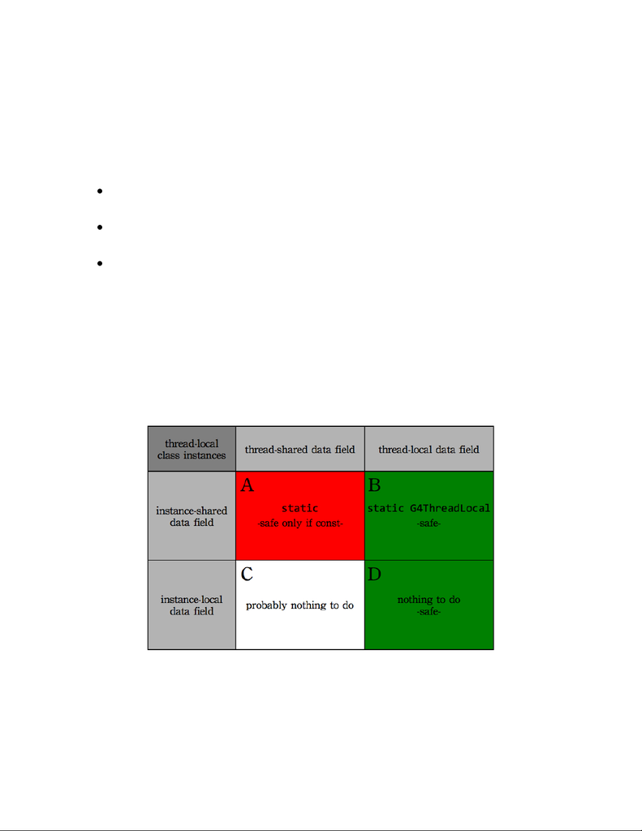

One or more instances of G4Class can exist at the same time in our

application. These instances can be thread-local (e.g. G4VProcess) or

thread-shared (e.g. G4LogicalVolume). In addition the class data field

fValue can be by itself thread-local or thread-shared. The actions to be taken

to transform the code depend on three key aspects:

Do we need to make the instance(s) of G4Class, thread-local or

thread-shared ?

Do we need to make the data field fValue , thread-local or thread-

shared ?

In case more than one instance of G4Class exits at the same time, do

we need fValue to be instance-local or instance-shared?

This gives rise to 8 different possible combinations, summarised in the

following figures, each one discussed in detail in the following.

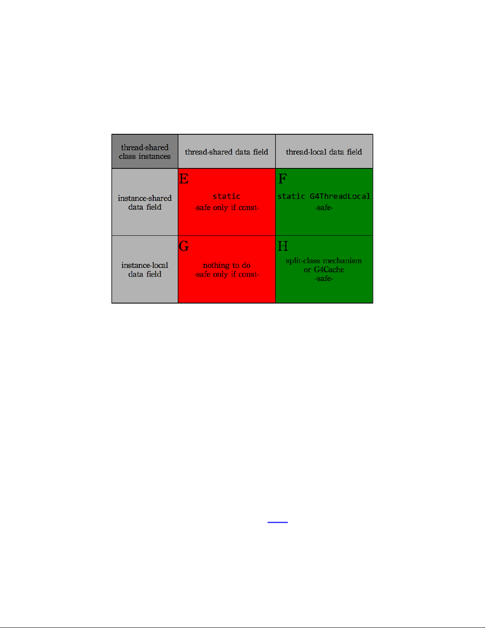

Fig. 28 Four of the eight possible scenarios for sharing of objects

Fig. 29 Four of the eight possible scenarios for sharing of objects

Case A: thread-local class instance(s), thread-shared and instance-

shared data field

In this case each thread has its own instance(s) of type G4Class. We need to

share fValue both among threads and among instances. As for a sequential

application, we can simply add the static keyword to the declaration of

fValue. This technique is common in Geant4 but has the disadvantage that

the resulting code is thread-unsafe (unless locks are used). Trying to add

const or modify its value (with the use of a lock) only outside of the event

loop is the simplest and best solution:

[figure not shown]

Case B: thread-local class instance(s), thread-local and instance-shared

data field.

This scenario is also common in Geant4: we need to share a variable (e.g. a

data table) between instances of the same class. However it is impractical or

it would lead to incorrect results if we share among threads fValue (i.e. the

penalty due to the need of locks is high or the data field holds a event-

dependent information). To make the code thread-safe we mark the data

field thread-local via the keyword G4ThreadLocal:

It should be noted that only simple data types can be declared

G4ThreadLocal. More information and the procedures to make an object

instance thread-safe via thread-local-storage are explained in this web-

page[#2].

Case C: thread-local class instance(s), thread-shared and instance-local

data field

One possible use-case is the need to reduce the application memory

footprint, providing a component to the thread-local instances of G4Class

that is shared among threads (e.g. a large cross-section data table that is

different for each instance). Since this scenario strongly depends on the

implementation details it is not possible to define a common strategy that

guarantees thread-safety. The best option is to try to make this shared

component const.

Case D: thread-local class instance(s), thread-local and instance-local

data field

class G4Class {

static const G4double fValue;

};

#include "G4Types.hh"

class G4Class {

static G4ThreadLocal G4double fValue;

};

[figure not shown]

This case is the simplest; nothing has to be changed in the original code.

Case E: thread-shared class instance(s), thread-shared and instance-

shared data field

With respect to thread-safety this case is equivalent to Case A, and the same

recommendations and comments hold.

Case F: thread-shared class instance(s), thread-local and instance-

shared data field

Concerning thread-safety this case is equivalent to Case B, and the same

recommendations and comments hold.

Since the class instances are shared among threads the data fields are

automatically thread-shared. No action is needed, however access to the

data fields is in general thread unsafe, and the same comments and

recommendations for Case A are valid.

Case H: thread-shared class instance(s), thread-local and instance-local

data field

This is the most complex case and it is relatively common in Geant4

Version 10.0. For example G4ParticleDefinition instances are shared

among the threads, but the G4ProcessManager pointer data field needs to

be thread- and instance-local. To obtain thread-safe code two possible

solutions exist:

Use the split-class mechanism. This requires some deep understanding

of Geant4 multi-threading and coordination with the kernel developers.

Split-classes result in thread-safe code with good CPU performance,

however they also require modification in other aspects of the kernel

category (in particular the run category). The idea behind the split-

[figure not shown]

class mechanism is that each thread-shared instance of G4Class

initialises the thread-local data fields by copying the initial status from

the equivalent instance of the master, which is guaranteed to be fully

configured. Additional details on split classes are available in a

dedicated section. An important side effect of the split-class

mechanism is that exactly the same number of instances of G4Class

must exist in each thread (e.g. the full set of G4Particles owned by the

master is shared by threads. If a new particle is created, this has to be

shared by all threads).

If performance is not a concern a simpler solution is available. This is

a simplified version of the split-class mechanism that does not copy

the initial status of the thread-local data field from the master thread. A

typical example is a cache variable that reduces CPU usage, storing in

memory the value of a CPU intensive calculation for several events. In

such a case the G4Cache utility class can be employed (see G4Cache).

Details on the split classes mechanism

We describe here the split-class mechanism, central to Geant4 multi-

threading, by developing a thread-safe split-class starting from our

simplified example of G4Class. It will be clear that this technique allows

for minimal changes of the public API of the classes and thus is very

suitable for making thread-safe code without breaking backward

compatibility.

To better describe the changes we introduce a setter and getter methods in

the sequential version of our class (e.g. before migration to multi-

threading):

class G4Class

{

private:

G4double fValue;

public:

G4Class() { }

void SetMyData( G4double aValue ) { fValue = aValue; }

G4double GetMyData() const { return fValue; }

};

[figure not shown]

Instances of this class will be shared among threads (because they are

memory-consuming objects) and we want to transform this class into a

split-class.

As a first step we add to the declaration of fValue the TLS keyword

G4ThreadLocal (in a POSIX system, this is a typedef to __thread).

Unfortunately there are several constraints on what can be specified as TLS.

In particular the data member has to be declared static (or be a global

variable):

The problem occurs if we need more than one instance of type G4Class

with an instance-local different value of fValue. How can this behaviour be

obtained now that the we have declared the data member as static? The

method used to solve this problem is called the split class mechanism. The

idea is to collect all thread-local data fields into a separate new class,

instances of which (one per original instance of G4Class) are organised in

an array. This array is accessed via an index representing a unique identifier

of a given class instance.

We can modify the code as follows:

#include "tls.hh"

class G4Class

{

private:

static G4ThreadLocal G4double fValue;

public:

G4Class() { }

void SetMyData( G4double aValue ) { fValue = aValue; }

G4double GetMyData() const { return fValue; }

};

G4ThreadLocal G4double G4Class::fValue = -1;

class G4ClassData {

public:

G4double fValue;

void initialize() {

fValue = -1;

}

};

[figure not shown]

As one can see, the use of the value of fValue variable is very similar to how

we use it in the original sequential mode, all the handling of the TLS is

done in the template class G4Splitter that can be implemented as:

typedef G4ClassManager G4ClassSubInstanceManager;

#define G4MT_fValue

((subInstanceManager.offset[gClassInstanceId]).fValue)

class G4Class {

private:

G4int gClassInstanceId;

static G4ClassSubInstanceManager subInstanceManager;

public:

G4Class()

{

gClassInstanceId =

subInstanceManager.CreateSubInstance();

}

void SetMyData( G4double aValue ) { G4MT_fValue = aValue; }

G4double GetMyData() const { return G4MT_fValue; }

};

G4ClassSubInstanceManager G4Class::subInstanceManager;

G4Splitter>G4ClassData<::workertotalspace = 0;

G4Splitter>G4ClassData<::offset = 0;

template <class T>

class G4Splitter

{

private:

G4int totalobj;

public:

static G4ThreadLocal G4int workertotalspace;

static G4ThreadLocal T* offset;

public:

G4Splitter() : totalobj(0) {}

G4int CreateSubInstance()

{

[figure not shown]

Let's consider a function that can be called concurrently by more than one

thread:

totalobj++;

if ( totalobj > workertotalspace ) { NewSubInstances();

}

return (totalobj-1);

}

void NewSubInstances()

{

if ( workertotalspace >=totalobj ) { return; }

G4int originaltotalspace = workertotalspace;

workertotalspace = totalobj + 512;

offset = (T*) realloc( offset , workertotalspace *

sizeof(T) );

if ( offset == 0 )

{

G4Exception("G4Splitter::NewSubInstances","OutOfMemory",FatalEx

ception,

"Cannot malloc space!");

}

{

offset[i].initialize();

}

}

void FreeWorker()

{

if ( offset == 0 ) { return; }

delete offset;

}

};

#include "G4Class.hh"

//Variables at global scope

G4Class a;

G4Class b;

void foo()

{

[figure not shown]

We expect that each thread will write on the screen: "0.1 0.2"

When we declare the variable a, the static object subInstanceManager in

memory has the state:

The constructor of G4Class calls CreateSubInstance, and since at this point

totalobj equals 1, G4Splitter::NewSubInstances() is called. This will create

a buffer of 512 pointers of type G4ClassData, each of which is initialised

(via G4ClassData::initialize()) to the value -1. Finally,

G4Splitter::CreateSubInstance() returns 0 and a.gClassInstanceId equals 0.

When a.SetMyData(0.1) is called, the call is equivalent to:

When now we declare the instance b the procedure is repeated, except that,

position in offset. Only if we create more than 512 instances of G4Class is

the memory array reallocated with more space for the new G4ClassData

instances.

Since offset and workertotalspace are marked G4ThreadLocal this

mechanism allows each thread to have its own copy of fValue. The function

foo() can be called from different threads and they will use the thread-

shared a and b to access a thread-local fValue data field. No data-race

condition occurs and there is no need for mutexes and locks.

An additional complication is that if the initialisation of the thread-local

part is not trivial and we want to copy some values from the corresponding

values of the master thread (in our example, how is fValue to be initialised

a.SetMyData(0.1); //First instance

b.SetMyData(0.2); //Second instance

G4cout << a.GetMyData()<< " "<< b.GetMyData() << G4endl;

}

totalobj = 0

TLS workertotalspace = 0

TLS offset = NULL

subInstanceManager.offset[0].fValue = 0.1;

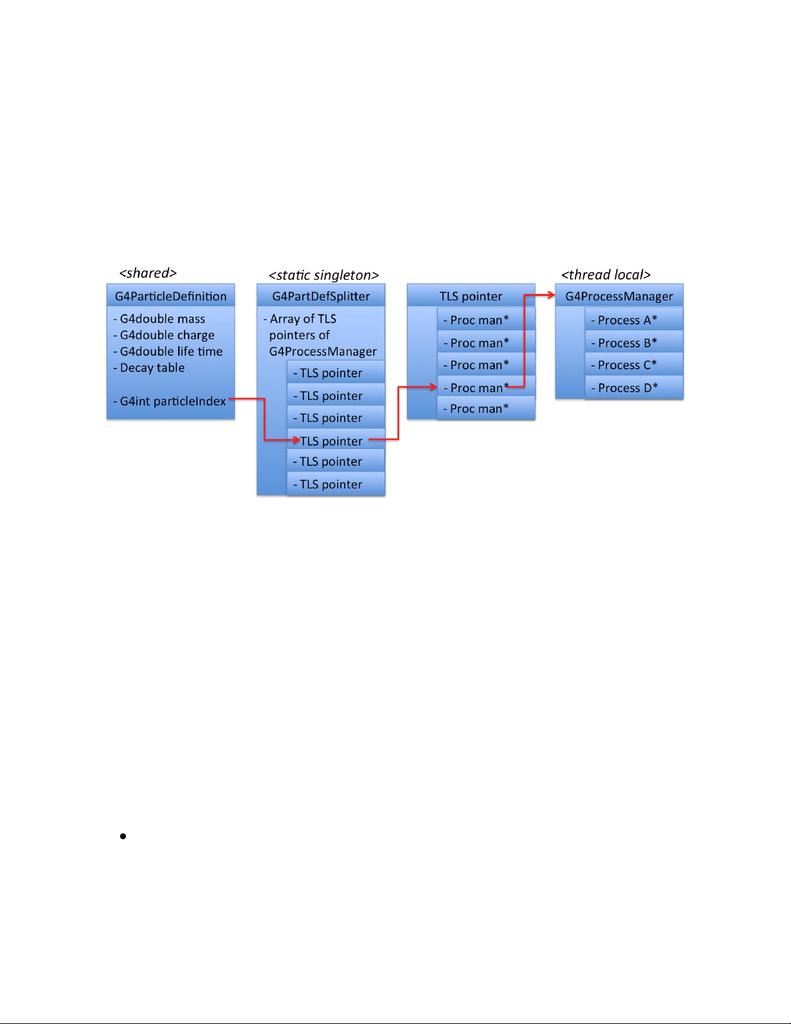

to a value that depends on the run condition?). The initial status of the

thread-local data field must be initialised, for each worker, in a controlled

way. The run category classes must be modified to prepare the TLS space of

each thread before any work is performed.

The following diagram shows the chain of calls in G4ParticleDefinition

when a thread needs to access a process pointer:

Fig. 30 Simplified view of the split-class mechanism

Note

A note on content of split classes. Data fields of the split class should

have a size that is known at compile time. Thus objects like std::vector

cannot be contained in split class data, but pointers to these object can.

List of split-classes

In Geant4 Version 10.0 the following are split-classes:

For geometry related split classes the class G4GeomSplitter

implements the split-class mechanism. These are the geometry-related

split-classes:

i. G4LogicalVolume

[figure not shown]

ii. G4PhysicalVolume

iii. G4PVReplica

iv. G4Region

v. G4PolyconeSide

vi. G4PolyhedraSide

For Physics related split-classes the classes G4PDefSplitter and

G4VUPLSplitter implement the split-class mechanism. These are the

physics-related split-classes:

i. G4ParticleDefinition

ii. G4VUserPhysicsList

iii. G4VModularPhysicsList

iv. G4VPhysicsConstructor

Explicit memory handling

In the following, some utility classes and functions to help memory

handling are discussed. Before going into detail it should be noted that all

of these utilities have a (small) CPU and memory performance penalty; they

should be used with caution and only if other simpler methods are not

possible. In some cases limitations are present.

The template class G4Cache

In many cases the full functionality of split-classes is not needed and what

we really want are independent thread-local and instance-local data fields in

thread-shared instances of G4Class. A concrete example would be a class

representing a cross-section that is made shared because of its memory

footprint. It requires a data field to act as a cache to store the value of a

CPU intensive calculation. Since different threads share this instance we

need to transform the code in a manner similar to what we do for the split-

class mechanism. The helper class G4Cache can be used for this purpose

(note that the complication of the initial value of the thread-local data field

is not present in this case).

G4Cache is a template class that implements a light-weight split-classes

mechanism. Being a template it allows for storing any user-defined type.

The public API of this class is very simple and it provides two methods:

[figure not shown]

to access a thread-local instance of the cached object. For example:

Since Get returns a reference to the cached object is possible to avoid the

use of Put to update the cache:

In case the cache holds an instance of an object it is possible to implement

lazy initialisation, as in the following example:

T& G4Cache<T>::Get() const;

void G4Cache<T>::Put(const T& val) const;

#include "G4Cache.hh"

class G4Class {

G4Cache<G4double> fValue;

void foo() {

// Store a thread-local value

G4double val = someHeavyCalc();

fValue.Put( val );

}

void bar() {

//Get a thread-local value:

G4double local = fValue.Get();

}

};

void G4Class::bar() {

//Get a reference to the thread-local value:

G4double &local = fValue.Get();

// Use local as in the original sequential code, cache is

updated, without the need to use Put

local++;

}

#include "G4Cache.hh"

class G4Class {

G4Cache<G4Something*> fValue;

void bar() {

//Get a thread-local value:

G4Something* local = fValue.Get();

if ( local == 0 ) {

local = new G4Something( ... );

//warning this may cause a memory leak. Use of

[figure not shown]

Since the use of G4Cache implies some CPU penalty, it is good practice to

try to minimise its use. For example, do not use a single G4Cache for

several data fields; instead use a helper structure as the template parameter

for G4Cache:

Two specialised versions of G4Cache exist that implement the semantics of

std::vector and std::map

G4VectorCache<T> implements a thread-local std::vector<T> with

methods Push_back(...), operator[], Begin(), End(), Clear(), Size() and

Pop_back()

G4MapCache<K,V> implements a thread-local std::map<K,V> with

methods Insert(...), Begin(), End(), Find(…), Size(), Get(…), Erase(…),

operator[] and introduces the method Has(...)

A detailed example of the use of these cache classes is discussed in the unit

test source/global/management/test/testG4Cache.cc.

G4AutoDelete namespace

During the discussion of G4Cache we have shown the example of storing a

pointer to a dynamically created object. A common problem is to correctly

delete this object at the end of its life-cycle. Since the G4Class instance is

thread-shared, it is not possible to delete the cached object in the destructor

of G4Class because it is called by the master and the thread-local instances

of the cached object will not be deleted. In some cases, to solve this

G4AutoDelete can help, see later

}

}

};

class G4Class {

struct {

G4double fValue1;

G4Something* fValue2;

} ToBeCached_t;

G4Cache<ToBeCached_t> fCache;

};

[figure not shown]

problem, it is possible to use a helper introduced in the namespace

G4AutoDelete. A simplified garbage collection mechanism without

reference counting is implemented:

This technique will delete all instances of the registered objects at the end

of the program, after the main function has returned (if they were declared

static).

This method has several limitations:

i. Registered objects will be deleted only at the end of the program

ii. The order in which objects of different type will be deleted is not

specified

iii. Once an object is registered it cannot be deleted anymore explicitly by

user

iv. The objects that are registered with this method cannot contain data

filed marked G4ThreadLocal and cannot be a split-classes

v. Registered object cannot make use of G4Allocator functionalities

vi. These restrictions apply to all data members for which the class owns

property

In addition, since the objects will be deleted in a non-specified order after

the main program exit, it is recommended to provide a very simple

destructor that does not depend on other objects (in particular should not

call any kernel functionality).

Thread Private singleton

#include "G4AutoDelete.hh"

void G4Class::bar() {

//Get a thread-local value:

G4Something* local = fValue.Get();

if ( local == 0 ) {

local = new G4Something( ... );

G4AutoDelete::Register( local ); //All thread

instances will be delete automatically

}

}

[figure not shown]

In Geant4 the singleton pattern is used in several cases. The majority of the

managers are implemented via the singleton pattern, the simplest of which

is:

With multi-threading, many managers and singletons are thread-local. For

this reason they have been transformed to:

This causes a memory leak: it is not possible to delete thread-local instances

of the singletons. To solve this problem the class G4ThreadLocalSingleton

has been added to the toolkit. This template class has a single public

method T* G4ThreadLocalSingleton<T>::Instance() that returns a pointer

to a thread-local instance of T. The thread-local instances of T will be

deleted, as in the case of G4Cache, at the end of the program.

The example code can be transformed to:

class G4Singleton {

public:

G4Singleton* GetInstance() {

static G4Singleton anInstance;

return&anInstance;

}

};

class G4Singleton {

private:

static G4ThreadLocal* instance;

public:

G4Singleton* GetInstance() {

if ( instance == 0 ) instance = new G4Singleton;

return instance;

}

};

#include "G4ThreadLocalSingleton.hh"

class G4Singleton {

friend class G4ThreadLocalSingleton<G4Singleton>;

public:

G4Singleton* GetInstance() {

static G4ThreadLocalSingleton<G4Singleton> theInstance;

return theInstance.Instance();

[figure not shown]

Threading model utilities and functions

Geant4 parallelism is based on POSIX standards and in particular on the

pthreads library. However all functionalities have been wrapped around

Geant4 specific names. This allows the inclusion of the WIN32 threading

model. In the following, the main functionalities available in the

global/management category are discussed.

Types and functions related to the use of threads

G4Thread defines the type for threads (POSIX pthread_t). The types

G4ThreadFunReturnType and G4ThreadFunArgType define

respectively the return value and the argument type for a function executed

in a thread. Use G4THREADCREATE and G4THREADJOIN macros to

respectively create and join a thread. G4Pid_t is the type for the PID of a

thread.

Example:

}

};

#include "G4Threading.hh"

//Define a thread-function using G4 types

G4ThreadFunReturnType myfunc( G4ThreadFunArgType val) {

double value = *(double*)val;

MESSAGE("value is:"<<value);

return /*(G4ThreadFunReturnType)*/NULL;

}

//Example: spawn 10 threads that execute myfunc

int main(int,char**) {

MESSAGE( "Starting program ");

int nthreads = 10;

G4Thread* tid = new G4Thread[nthreads];

double *valss = new double[nthreads];

for ( int idx = 0 ; idx < nthreads ; ++idx ) {

valss[idx] = (double)idx;

[figure not shown]

Types and functions related to the use of mutexes and

conditions

G4Mutex is the type for mutexes in Geant4 (POSIX pthread_mutex_t).

The G4MUTEX_INITIALIZER and G4MUTEXINIT macros are used to

initialise a mutex. Use G4MUTEXLOCK and G4MUTEXUNLOCK

functions to lock/unlock a mutex. The G4AutoLock class helps the

locking/unlocking of a mutex and should be always be used instead of

G4MUTEXLOCK/UNLOCK.

Example:

G4THREADCREATE(&(tid[idx]) , myfunc,&(valss[idx]) );

}

for ( int idx = 0 ; idx < nthreads ; ++idx ) {

G4THREADJOIN( (tid[idx]) );

}

MESSAGE( "Program ended ");

return 0;

}

#include "G4Threading.hh"

#include "G4AutoLock.hh"

//Create a global mutex

G4Mutex mutex = G4MUTEX_INITIALIZER;

//Alternatively, call in the main function G4MUTEXINIT(mutex);

//A shared resource (i.e. manipulated by all threads)

G4int aValue = 1;

G4ThreadFunReturnType myfunc( G4ThreadFunArgType ) {

//Explicit lock/unlock

G4MUTEXLOCK(&mutex );

++aValue;

G4MUTEXUNLOCK(&mutex );

//The following should be used instead of the previous

because it guarantees automatic

//unlock of mutex.

//When variable l goes out of scope, G4MUTEXUNLOCK is

automatically called

[figure not shown]

A complete example of the usage of these functionalities is discussed in the

unit test source/global/management/test/ThreadingTest.cc.

Conditions are also available via the G4Condition type, the

G4CONDITION_INITIALIZER macro and the two functions

G4CONDITIONWAIT and G4CONDITIONBROADCAST. The use of

conditions allows the barrier mechanism (e.g. synchronisation point for

threads) to be implemented. A detailed example on the use of conditions

and how to implement correctly a barrier is discussed in

G4MTRunManager code (at the end of file

source/run/src/G4MTRunManager.cc). In general there should be no need

for kernel classes (with the exception of run category) to use conditions

since threads are considered independent and do not need to communicate

between them.

Random Number Generation Seeding in MT

The seeding strategy in MT mode is based on the requirement to guarantee

full reproducibility. This means that each even has to be preassigned a seed

that allows the simulation of that particular event to be run independently

on the job configuration (e.g. number of threads).

Before worker threads are spawned, the master thread pre-generates random

number seeds that are coupled to the event number. For efficiency reasons

the seeds are generated for a block of events (the event modulo, see UI

command /run/eventModulo). In addition the user can derive from the

G4AutoLock l(&mutex);

--aValue;

//Explicit lock/unlock. Note that lock/unlock is only tried

if mutex is already locked/unlock

l.lock();

l.lock();//No problem here

++aValue;

l.unlock();

l.lock();

--aValue;

return /*(G4ThreadFunReturnType)*/NULL;

}

[figure not shown]

G4MTRunManager class and implement their own strategy re-

implementing the function, called by the master thread during run

initialisation: virtual G4bool

G4MTRunManager::InitializeSeeds(G4int) { return false; }.

In this function the user should do:

It is important to note that the MIXMAX random number generator

(available since version 10.3) is the recommended engine for MT jobs since

it guarantees divergent number histories even for consecutive random

number seeds.

Additional material

In this chapter we discussed in detail what are probably the most critical

aspects of multi-threading capabilities in Geant4. Additional material can

be found in online resources. The main entry point is the Geant4 multi-

threading task-force twiki page[#3]. The Application Developers Guide

contains general information regarding multi-threading that is also relevant

for Toolkit Developers.

G4bool MyRunManager::InitializeSeeds(G4int nEvents ) {

//Generate as desired seeds for the run w/ nEvents

//...

auto helper = G4RNGHelper::GetInstance();

helper->Clear();//To remove any seed from previous run

//Fill seeds one by one, use:

helper->AddOneSeed( seed );

//Or fill many:

assert( size(seedsArray) == numEvents*number_seeds_per_event

);

helper->Fill( seedsArray , numEvents , numEvents ,

number_seeds_per_event);

//Next line is very important, to avoid retriggers of fills

from kernel with default strategy/

//Communicate how many events are ready

G4MTRunManager::nSeedsFilled = numEvents;

return true;

}

[figure not shown]

[#1]

[#2]

[#3]

[#4]

A beginner's guide to multi-threading targeted to Geant4 developers has

been presented during the 18th Collaboration Meeting: agenda[#4]

For additional information consult this page[#5] and this page[#6]

Several contributions at the 18th Collaboration Meeting[#7] discuss multi-

threading:

Plenary Session 3 - Geant4 version 10 (part 1): agenda[#8]

Hadronics issues related to MT: agenda[#9]

Developments for multi-threading: work-spaces: contribution[#10]

Status of the planned developments: coding guidelines, MT migration,

g4tools migration, code review: contribution[#11]

G4MT CP on MIC Architecture: contribution[#12]

Finally, a few articles and proceedings have been prepared:

X. Dong et al., Creating and Improving Multi-Threaded Geant4,

Journal of Physics: Conference Series 396, no. 5, p. 052029.

X. Dong et al., Multithreaded Geant4: Semi-automatic Transformation

into Scalable Thread-Parallel Software, Euro-Par 2010 - Parallel

Processing (2010), vol. 6272, pp. 287-303.

S. Ahn et al., Geant4-MT: bringing multi-threaded Geant4 into

production, to be published in SNA&MC2013 proceeding

Footnotes

http://en.wikipedia.org/wiki/Thread-local_storage

https://twiki.cern.ch/twiki/bin/view/Geant4/Geant4MTTipsAndTricks

#4_Why_I_cannot_simply_add_G4Thre

https://twiki.cern.ch/twiki/bin/view/Geant4/MultiThreadingTaskForce

https://indico.cern.ch/getFile.py/access?

contribId=3&sessionId=7&resId=0&materialId=slides&confId=25002

1

[figure not shown]

[#5]

[#6]

[#7]

[#8]

[#9]

[#10]

[#11]

[#12]

https://twiki.cern.ch/twiki/bin/view/Geant4/Geant4MTAdvandedTopic

sForApplicationDevelopers

https://twiki.cern.ch/twiki/bin/view/Geant4/Geant4MTTipsAndTricks

http://congreso.us.es/geant42013/

https://indico.cern.ch/sessionDisplay.py?

sessionId=7&amp;confId=250021#20130924

https://indico.cern.ch/sessionDisplay.py?

sessionId=22&amp;confId=250021#20130926

https://indico.cern.ch/contributionDisplay.py?

contribId=20&amp;confId=250021

https://indico.cern.ch/contributionDisplay.py?

contribId=128&amp;confId=250021

https://indico.cern.ch/contributionDisplay.py?

contribId=37&amp;confId=250021

[figure not shown]

Extending Toolkit Functionality

Contents:

Geometry

What can be extended ?

Adding a new type of Solid

Modifying the Navigator

Electromagnetic Fields

Creating a New Type of Field

A new Field class

A new Equation of Motion for the new Field

Get a G4FieldManager to use your field

Changes for non-electromagnetic fields

Particles

Properties of particles

Properties of nuclei

Changing particle properties

Adding New Particles

Nuclide properties from the Evaluated Nuclear Structure Data

File

G4NuclideTable

Adding states

Electromagnetic Physics

Introduction

General design

Electromagnetic processes

Electromagnetic models

Hadronic Physics

Introduction

Principal Considerations

Level 1 Framework - processes

Requirements

Design and interfaces

Framework functionality

[figure not shown]

Level 2 Framework - Cross Sections and Models

Requirements

Design and interfaces

Cross-sections

Final state production

Isotope production

Framework functionality

Cross Sections

Final state production

Isotope production

Level 3 Framework - Theoretical Models

Requirements

Design and interfaces

Framework functionality

Level 4 Frameworks - String Parton Models and Intra-Nuclear

Cascade

Requirements

Design and interfaces

Framework functionality

Level 5 Framework - String De-excitation

Requirements

Design and interfaces

Framework functionality

Creating Your Own Hadronic Process

Developing a new hadronic model

Developing a new cross section set

Developing a new hadronic process

Changing Internal Parameters of an Existing Hadronic Model

Advanced Interface to Change the Parameters of the Bertini

Cascade Model

Advanced Interface to Change the Parameters of the Fritiof

(FTF) Model

Changing internal parameters of an existing model: Fritiof

(FTF) use-case

Changing parameters of an existing model: Lund use-case

Generic Event Biasing

Introduction

[figure not shown]

Design of Generic Biasing

The G4VBiasingOperation Interface Class

The G4VBiasingOperator Interface Class

Physics Process Occurrence Biasing

Formalism for occurrence biasing

Implementation of Occurrence Biasing

Visualisation

Creating a new graphics driver

Important Command Actions

What happens in DrawView?

What happens in ProcessView?

What happens in ProcessScene?

Dealing with transient objects

More about scene models

Adding a new view parameter

Enhanced Trajectory Drawing

Creating a new trajectory model

Adding interactive functionality

Trajectory Filtering

Creating a new trajectory filter model

Adding interactive functionality

Other Resources

Footnotes

Geometry

What can be extended ?

Geant4 allows a user to describe a wide variety of shapes, and to use them

as solids in a detector description. In some cases, however, the user may

want or need to extend Geant4's geometry. Solids bounded by cubic or

higher order surfaces, or specialised shapes such as tubes twisted on a helix

would require a new type of solid. Another reason could be that the user is

looking to obtain a speedup by utilising specialised knowledge about his or

her geometry - compared to types of solids and implementations which are

more general. The most evident case of this occurs when a particular and

complex type of solid is a key element for a specific detector geometry; in

that case the investment in improving its runtime performance may be

worthwhile.

To extend the functionality of the Geometry in this way, a toolkit developer

must implement nine methods required for a new solid. We list these

methods below and document their specifications. Note that the

implementation of several methods are not a trivial matter: these methods

must find whether a point is inside a solid, calculate the intersection of a

line with the solid, and estimate the minimum distance to the solid along

any direction. Once the new solid class has been created, having fulfilled all

its specifications by implements the abstract interface of the G4VSolid base

class, it can be used like any Geant4 solid,

Other additions can also potentially be achieved. For example, an advanced

user could add a new way of creating physical volumes. However, because

each type of volume has a corresponding navigator helper, this requires

creating a new type of Navigator as well. To do this the user have to inherit

from G4Navigator and modify the new Navigator to handle this type of

volumes.

Since Geant4 10.6 a new way has been provided to extend the geometry

description and G4Navigator using an external geometry modeller. This can

[figure not shown]

be used to support alternative types of physical volumes.

Adding a new type of Solid

We list below the required methods for integrating a new type of solid in

Geant4. Note that Geant4's specifications for a solid pay significant

attention to what happens at points that are within a small distance

(tolerance, kCarTolerance in the code) of the surface. So special care must

be taken to handle these cases in considering all different possible

scenarios, in order to respect the specifications and allow the solid to be

used correctly by the other components of the geometry module.

Creating a derived class of G4VSolid

The solid must inherit from G4VSolid or one of its derived classes and

implement its virtual functions.

Mandatory member functions you must define are the following pure

virtual of G4VSolid:

They must perform the following functions

EInside Inside(const G4ThreeVector& p)

G4double DistanceToIn(const G4ThreeVector& p)

G4double DistanceToIn(const G4ThreeVector& p, const

G4ThreeVector& v)

G4ThreeVector SurfaceNormal(const G4ThreeVector& p)

G4double DistanceToOut(const G4ThreeVector& p)

G4double DistanceToOut(const G4ThreeVector& p, const

G4ThreeVector& v,

const G4bool calcNorm=false,

G4bool *validNorm=0, G4ThreeVector

*n)

G4bool CalculateExtent(const EAxis pAxis,

const G4VoxelLimits& pVoxelLimit,

const G4AffineTransform& pTransform,

G4double& pMin,

G4double& pMax) const

G4GeometryType GetEntityType() const

std::ostream& StreamInfo(std::ostream& os) const

[figure not shown]

This method must return:

kOutside if the point at offset p is outside the shape boundaries plus

Tolerance/2,

kSurface if the point is <= Tolerance/2 from a surface, or

kInside otherwise.

Return the outwards pointing unit normal of the shape for the surface

closest to the point at offset p.

Calculate distance to nearest surface of shape from an outside point p. The

distance can be an underestimate.

Return the distance along the normalised vector v to the shape, from the

point at offset p. If there is no intersection, return kInfinity. The first

intersection resulting from 'leaving' a surface/volume is discarded. Hence,

this is tolerant of points on surface of shape.

Calculate distance to nearest surface of shape from an inside point. The

distance can be an underestimate.

Return distance along the normalised vector v to the shape, from a point at

an offset p inside or on the surface of the shape. Intersections with surfaces,

EInside Inside(const G4ThreeVector& p)

G4ThreeVector SurfaceNormal(const G4ThreeVector& p)

G4double DistanceToIn(const G4ThreeVector& p)

G4double DistanceToIn(const G4ThreeVector& p, const

G4ThreeVector& v)

G4double DistanceToOut(const G4ThreeVector& p)

G4double DistanceToOut(const G4ThreeVector& p, const

G4ThreeVector& v,

const G4bool calcNorm=false,

G4bool *validNorm=0, G4ThreeVector

*n=0);

[figure not shown]

when the point is not greater than kCarTolerance/2 from a surface, must be

ignored.

If calcNorm is true, then it must also set validNorm to either

true, if the solid lies entirely behind or on the exiting surface. Then it

must set n to the outwards normal vector (the Magnitude of the vector

is not defined).

false, if the solid does not lie entirely behind or on the exiting surface.

If calcNorm is false, then validNorm and n are unused.

Calculate the minimum and maximum extent of the solid, when under the

specified transform, and within the specified limits. If the solid is not

intersected by the region, return false, else return true.

Provide identification of the class of an object (required for persistency and

STEP interface).

Should dump the contents of the solid to an output stream.

The method:

should be implemented for every solid to provide a way to clone themselves

in a new object with same specifications.

The method:

G4bool CalculateExtent(const EAxis pAxis,

const G4VoxelLimits& pVoxelLimit,

const G4AffineTransform& pTransform,

G4double& pMin,

G4double& pMax) const

G4GeometryType GetEntityType() const;

std::ostream& StreamInfo(std::ostream& os) const

G4VSolid* Clone() const

[figure not shown]

returns a random point located on the surface of the solid. Points returned

should not necessarily be uniformly distributed.

The method:

should be implemented for every solid in order to cache the computed value

(and therefore reuse it for future calls to the method) and to eventually

implement a precise computation of the solid's volume. If the method will

not be overloaded, the default implementation from the base class will be

used (estimation through a Monte Carlo algorithm) and the computed value

will not be stored.

The method:

should be implemented for every solid in order to cache the computed value

(and therefore reuse it for future calls to the method) and to eventually

implement a precise computation of the solid's surface area. If the method

will not be overloaded, the default implementation from the base class will

be used (estimation through a Monte Carlo algorithm) and the computed

value will not be stored.

There are a few member functions to be defined for the purpose of

visualisation. The first method is mandatory, and the next four are not.

G4ThreeVector GetPointOnSurface() const

G4double GetCubicVolume()

G4double GetSurfaceArea()

// Mandatory

virtual void DescribeYourselfTo (G4VGraphicsScene& scene) const

= 0;

// Not mandatory

virtual G4VisExtent GetExtent() const;

virtual G4Polyhedron* CreatePolyhedron () const;

virtual G4NURBS* CreateNURBS () const;

virtual G4Polyhedron* GetPolyhedron () const;

[figure not shown]

What these methods should do and how they should be implemented is

described here.

This method is required in order to identify the solid to the graphics scene.

It is used for the purposes of "double dispatch". All implementations should

be similar to the one for G4Box:

The method:

provides extent (bounding box) as a possible hint to the graphics view. You

must create it by finding a box that encloses your solid, and returning a

VisExtent that is created from this. The G4VisExtent must presumably be

given the minus x, plus x, minus y, plus y, minus z and plus z extents of this

"box". For example a cylinder can say

The method:

is required by the visualisation system, in order to create a realistic

rendering of your solid. To create a G4Polyhedron for your solid, consult

G4Polyhedron.

While the method:

void DescribeYourselfTo (G4VGraphicsScene& scene) const;

void G4Box::DescribeYourselfTo (G4VGraphicsScene& scene) const

{

scene.AddSolid (*this);

}

G4VisExtent GetExtent() const;

G4VisExtent G4Tubs::GetExtent() const

{

// Define the sides of the box into which the G4Tubs instance

would fit.

return G4VisExtent (-fRMax, fRMax, -fRMax, fRMax, -fDz, fDz);

}

G4Polyhedron* CreatePolyhedron () const;

[figure not shown]

is a "smart" access function that creates on requests a polyhedron and stores

it for future access and should be customised for every solid.

Modifying the Navigator

For the vast majority of use-cases, it is not indeed necessary (and definitely

not advised) to extend or modify the existing classes for navigation in the

geometry. A potential use-case for which this may apply, is for the

description of a new kind of physical volume to be integrated. We believe

that our set of choices for creating physical volumes is varied enough for

nearly all needs. Future extensions of the Geant4 toolkit will probably make

easier exchanging or extending the G4Navigator, by introducing an

abstraction level simplifying the customisation. At this time, a simple

abstraction level of the navigator is provided by allowing overloading of the

relevant functionalities.

Extending the Navigator

The main responsibilities of the Navigator are:

locate a point in the tree of the geometrical volumes;

compute the length a particle can travel from a point in a certain

direction before encountering a volume boundary;

estimating the minimum distance from a point to the nearest boundary,

either to the surface of the current volume or to of one of its daughter

volumes.

The Navigator utilises one helper class for each type of physical volume

that exists. You will have to reuse the helper classes provided in the base

Navigator or create new ones for the new type of physical volume.

To extend G4Navigator you will have then to inherit from it and modify

these functions in your ModifiedNavigator to request the answers for your

new physical volume type from the new helper class. The

G4Polyhedron* GetPolyhedron () const;

ModifiedNavigator should delegate other cases to the Geant4's standard

Navigator.

Using External Geometry Modeller for part of a geometry

Revisions in Geant4 10.6 introduced the ability to select part of a geometry

description for navigation by an external geometry modeller. This external

The selected logical volumes must be filled with a new type of 'external'

physical volume, a new umbrella type of physical volume whose

classification is as type 'kExternal'. This is used to signal that a new external

subnavigation class will undertake what the necessary intersection and

volume location methods.

This subnavigation class must inherit from the new abstract class

G4VExternalNavigation.

Replacing the Navigator

Replacing the Navigator is another possible operation. All types of physical

volume that will be allowed must be handled by it. The same functionality

is required as described in the previous section.

However the amount of work is probably potentially larger, if support for

all the current types of physical volumes is required.

The Navigator utilises one helper class for each type of physical volume

that exists. These could also potentially be replaced, allowing a simpler way

to create a new navigation system.

Footnotes

[figure not shown]

Electromagnetic Fields

Creating a New Type of Field

Geant4 currently handles magnetic and electric fields and, in future

releases, will handle combined electromagnetic fields. Fields due to other

forces, not yet included in Geant4, can be provided by describing the new

field and the force it exerts on a particle passing through it. For the time

being, all fields must be time-independent. This restriction may be lifted in

the future.

In order to accommodate a new type of field, two classes must be created: a

field type and a class that determines the force. The Geant4 system must

then be informed of the new field.

A new Field class

A new type of Field class may be created by inheriting from G4Field

and deciding how many components your field will have, and what each

component represents. For example, three components are required to

describe a vector field while only one component is required to describe a

scalar field.

If you want your field to be a combination of different fields, you must

choose your convention for which field goes first, which second etc. For

example, to define an electromagnetic field we follow the convention that

class NewField : public G4Field

{

public:

void GetFieldValue( const double Point[3],

double *pField )=0;

}

[figure not shown]

components 0,1 and 2 refer to the magnetic field and components 3, 4 and 5

refer to the electric field.

By leaving the GetFieldValue method pure virtual, you force those users

who want to describe their field to create a class that implements it for their

detector's instance of this field. So documenting what each component

means is required, to give them the necessary information.

For example someone can describe DetectorAbc's field by creating a class

DetectorAbcField, that derives from your NewField

They then implement the function GetFieldValue

A new Equation of Motion for the new Field

Once you have created a new type of field, you must create an Equation of

Motion for this Field. This is required in order to obtain the force that a

particle feels.

To do this you must inherit from G4Mag_EqRhs and create your own

equation of motion that understands your field. In it you must implement

the virtual function EvaluateRhsGivenB. Given the value of the field, this

class DetectorAbcField : public NewField

{

public:

void MyFieldGradient::GetFieldValue( const double

Point[3],

double *pField );

}

void MyFieldGradient::GetFieldValue( const double Point[3],

double *pField )

{

// We expect pField to point to pField[9];

// This & the order of the components of pField is your own

// convention

// We calculate the value of pField at Point ...

}

[figure not shown]

function calculates the value of the generalised force. This is the only

function that a subclass must define.

In particular, the derivative vector dydx is a vector with six components.

The first three are the derivative of the position with respect to the curve

length. Thus they should set equal to the normalised velocity, which is

components 3, 4 and 5 of y.

The next three components are the derivatives of the velocity vector with

respect to the path length. So you should write the "force" components for

for your field.

Get a G4FieldManager to use your field

In order to inform the Geant4 system that you want it to use your field as

the global field, you must do the following steps:

1. Create a Stepper of your choice:

2. Create a chord finder that uses your Field and Stepper. You must also

give it a minimum step size, below which it does not make sense to

attempt to integrate:

virtual void EvaluateRhsGivenB( const G4double y[],

const G4double B[3],

G4double dydx[] ) const =

0;

(dydx[0], dydx[1], dydx[2]) = (y[3], y[4], y[5])

dydx[3], dydx[4] and dydx[5]

yourStepper = new G4ClassicalRK( yourEquationOfMotion );

// or if your field is not smooth eg

// new G4ImplicitEuler( yourEquationOfMotion

);

yourChordFinder= new G4ChordFinder( yourField,

yourMininumStep, // say 0.01*mm

[figure not shown]

3. Next create a G4FieldManager and give it that chord finder,

4. Finally we tell the Geometry that this FieldManager is responsible for

creating a field for the detector.

Changes for non-electromagnetic fields

If the field you are interested in simulating is not electromagnetic, another

minor modification may be required. The transportation currently chooses

whether to propagate a particle in a field or rectilinearly based on whether

the particle is charged or not. If your field affects non-charged particles, you

must inherit from the G4Transportation and re-implement the part of

GetAlongStepPhysicalInteractionLength that decides whether the particles

is affected by your force.

In particular the relevant section of code does the following:

and you want it to ask whether it feels your force. If, for the sake of an

example, you wanted to see the effects of gravity on a heavy hypothetical

particle, you could say

yourStepper );

yourFieldManager= new G4FieldManager();

yourFieldManager.SetChordFinder(yourChordFinder);

G4TransportationManager::GetTransportationManager()

-> SetFieldManager( yourFieldManager

);

// Does the particle have an (EM) field force exerting upon

it?

//

if( (particleCharge!=0.0) ){

fieldExertsForce= this->DoesGlobalFieldExist();

// Future: will/can also check whether current volume's

field is Zero or

// set by the user (in the logical volume) to be zero.

}

[figure not shown]

After doing all these steps, you will be able to see the effects of your force

on a particle's motion.

Footnotes

// Does the particle have my field's force exerted on it?

//

if (particle->GetName() == "VeryHeavyWIMP") {

fieldExertsForce= this->DoesGlobalFieldExist(); // For

gravity

}

Particles

Properties of particles

The G4ParticleDefinition class contains the properties which characterize

individual particles, such as name, mass, charge, spin, and so on. Properties

of particles are set during the initialization of each particle type. The default

values of these properties are described in each particle class. In the case of

heavy nuclei properties may be given by external files. Once initialized,

particle properties cannot be changed except for those related to its decay;

these are life time, branching ratio of each decay mode and the "stable"

flag. Geant4 provides a method to override these properties by using

external files.

Properties of nuclei

Individual classes are provided for light nuclei (i.e. deuteron, triton, He3,

and He4) with default values of their properties. Other nuclei are

dynamically created by requests from processes (and users). G4IonTable

class handles the creation of such ions. Default properties of nuclei are

determined with help of G4NuclearProperties.

Users can register a G4IsotopeTable to the G4IonTable. G4IsotopeTable

which describes the properties used to create ions. Excitation energy, decay

modes, and life times for relatively long-lived nuclei can be obtained by

using G4RIsotopeTable and data files such as those pointed to by the

G4RADIOACTIVEDATA environment variable.

G4IsotopeMagneticMomentTable provides a table of nuclear magnetic

moments using the data file G4IsotopeMagneticMoment.table. The

environment variable G4IONMAGNETICMOMENT should be set to point

to this file.

Changing particle properties

[figure not shown]

Only in the "PreInit" phase can properties be modified with the help of the

G4ParticlePropertyTable class. Particle properties can be overridden with

the method

by setting new values in G4ParticlePropertyData. In addition, the current

particle property values can be extracted to text files by using

G4TextPPReporter. On the other hand, G4TextPPRetriever can change

particle properties according to text files.

Adding New Particles

A new particle can be added by creating a new class for it. The new class

should be derived from G4ParticleDefinition. You can find an example

under examples/extended/exoticphysics/monopole. There, the new class for

the monopole is defined as follows:

G4bool SetParticleProperty(const G4ParticlePropertyData&

newProperty)

class G4Monopole : public G4ParticleDefinition

{

private:

static G4Monopole* theMonopole;

G4Monopole(

const G4String& aName, G4double

mass,

G4double width, G4double

charge,

G4int iSpin, G4int

iParity,

G4int iConjugation, G4int

iIsospin,

G4int iIsospin3, G4int

gParity,

const G4String& pType, G4int

lepton,

G4int baryon, G4int

encoding,

G4bool stable, G4double

[figure not shown]

The static methods above must be defined and implemented so that the new

particle instance will be created in the ConstructParticles method of your

physics list. New properties may be added if necessary (G4Monopole has a

a property for magnetic charge). Values of properties need to be given in the

static method as other particle classes.

Nuclide properties from the Evaluated Nuclear

Structure Data File

G4NuclideTable

G4NuclideTable was introduced in Geant4 v10 to provide properties of

nuclides. The excitation energy and decay constant of each of 25,497 states

are listed in the table and the spin and dipole magnetic moments are

lifetime,

G4DecayTable *decaytable );

public:

virtual ~G4Monopole();

static G4Monopole* MonopoleDefinition();

static G4Monopole* Monopole();

}

G4Monopole* G4Monopole::MonopoleDefinition(G4double mass, G4int

mCharge, G4int eCharge)

{

if(!theMonopole) {

theMonopole = new G4Monopole(

"monopole", mass, 0.0*MeV,

0,

0, 0, 0,

0, 0, 0,

"boson", 0, 0,

0,

true, -1.0, 0);

}

return theMonopole;

}

[figure not shown]

available for some states. The source of these data is ENSDF as of February

2015. In Geant4 v10.02 the hard-coded list of the nuclide states was

removed and it now uses only the ENSDFSTATE.dat. G4NuclideTable

fills this array by scanning the file and selecting all nuclides with half-lives

greater than 1.0 microsecond.

The user may set the minimum half-life of states that will be selected during

the scan of ENSDFSTATE.dat. If that value is less than the default of 1

microsecond, more states will be read into G4NuclideTable. If it is larger,

fewer states will be included. Any nuclide thus read into G4NuclideTable

will be treated as a track-able particle, which will travel some distance as

sampled from its decay time. For each state, G4NuclideTable assigns a level

number ranging from 0 to the PDG limit of 9. All ground states are assigned

the value 0. In a given nucleus, the selected state with the smallest

excitation energy is assigned to be level 1, and so on for the subsequent

higher selected excitation energy states up to level 8. Note that the ordering

of states in a given nucleus will change depending on the minimum half-life

value chosen. If more than 8 excited states are found, the excess states are

all assigned to level 9. The above action is taken at initialization time and

may be invoked in two ways:

/particle/manage/nuclideTable/min\_halflife 0.001 ns

Note that while setting a small minimum half-life will provide a more

precise decay chain with more short-lived nuclides, the increased number of

states will reduce CPU performance and increase memory footprint.

Adding states

User may add states with user specified values of excitation energy, decay

constant, spin and dipole magnetic moment by:

G4NuclideTable::SetThresholdOfHalfLife (G4double)

AddState (G4int Z, G4int A , G4double excitation_energy,

G4double lifetime, G4int ionJ=0,

G4double ionMu=0.0)

[figure not shown]

This is done at initialization time and all values are read into the

G4NuclideTable array regardless of the minimum half-life value. These user

states are all assigned to level number 9.

In addition to the minimum half-life value, G4NuclideTable also allows the

user to set the tolerance level of the excitation energy used to identify the

state. The default value of the tolerance is 1 eV which the user may modify

in one of two ways:

/particle/manage/nuclideTable/level\_tolerance 1 keV

This modification is also done during the initialization phase. Note that in

adding states a user must specify excited states with a precision that

matches the tolerance. Thus, if the tolerance is 1 eV, the level in keV would

be given, for example, by 2505.531, otherwise that state will be missed. If it

is not desirable to specify levels to such a precision, the tolerance value can

be increased. If, however, there are two levels in a nucleus which are closer

to one another than the value of the tolerance, one of the levels will be

missed. Currently G4RadioactiveDecay and G4PhotoEvporation models

share the state information with G4NuclideTable. Other models are

encouraged to do likewise.

Footnotes

G4NuclideTable::SetLevelTolerance(G4double)

[figure not shown]

Electromagnetic Physics

Introduction

The Geant4 set of electromagnetic (EM) physics processes and models are

used in practically all types of simulation applications including high

energy and nuclear physics experiments, beam transport, medical physics,

cosmic ray interactions and radiation effects in space. In addition to models

for low and high energy EM physics for simulation of radiation effects in

media, a sub-library of very low energy models was developed within the

framework of the Geant4-DNA project, with the goal of simulating

radiation effects involving physics and chemistry at the sub-cellular level.

In the early stages of Geant4, low and high energy EM processes were

developed independently, with the result that these processes could not be

used in the same run. To resolve this problem, the interfaces were unified so

that the standard, muons, highenergy, lowenergy, and dna EM physics sub-

packages now follow the same design. Migration to this common design

resulted in an improvement of overall CPU performance, and made it

possible to provide several helper classes which are useful for a variety of

user applications (for example G4EmCalculator).

General design

The electromagnetic processes of Geant4 follow the basic interfaces:

G4VEnergyLossProcess;

G4VEmProcess;

G4VMultipleScattering.

The class diagram is shown in Fig. 31.

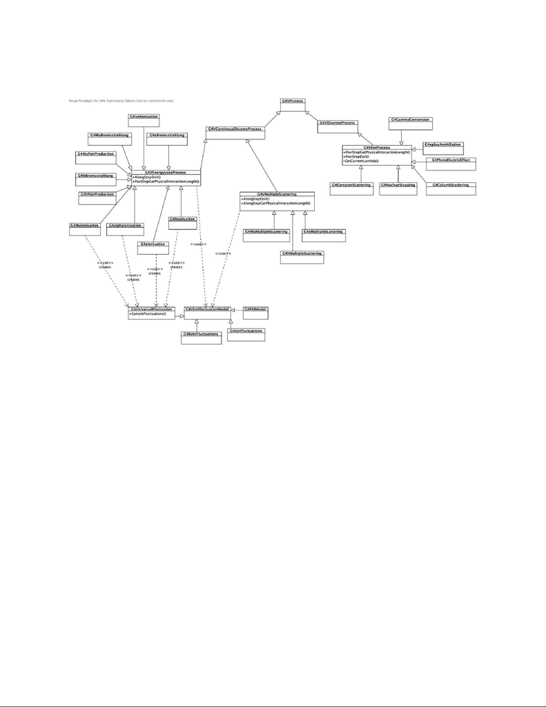

Fig. 31 Design of EM physics processes.

These common interfaces for all EM sub-packages enabled the full

migration of EM classes to multi-threading without significant modification

of existing physics model codes. Initialisation of the energy loss, stopping

power and cross section tables is carried out only once in the master thread

at the beginning of simulation. These tables are shared between threads in

run time.

Electromagnetic processes

These base classes provide all management work of initialisation of

processes, creation and filling of physics tables, and generic run-time

actions. Concrete process classes are responsible for the initialisation of

parameters and defining the set of models for the process. It is strongly

[figure not shown]

recommended to use existing processes and not create a new one for each

new model. Here is a list of main EM processes:

G4PhotoelectricEffect;

G4ComptonScattering;

G4GammaConversion;

G4GammaConversion;

G4RayleighScattering;

G4eIonisation;

G4eBremsstrahlung;

G4hIonisation;

G4MuIonisation;

G4hIonisation;

G4MuBremsstrahlung;

G4eMultipleScattering;

G4MuMultipleScattering.

More processes are provided in lowenergy, polarisation, and adjoint sub-

libraries. In some specific cases, interfaces described above are not

applicable and the high level interface G4VProcess is used.

Any concrete physics process class may need custom parameters. It is

recommended to define following parameters specific to the class in the

class constructor:

process sub-type;

buildTables flag;

secondary particle type;

min/max energy of cross section tables;

number of bins in tables;

flag to force zero cross section in the low edge of a table.

Any EM process should implement following methods:

IsApplicable(const G4ParticleDefinition& p)

ProcessDescription()

Main initialisation of a process is performed by initialisation methods:

[figure not shown]

InitialiseEnergyLossProcess(const G4ParticleDefinition*

part, const G4ParticleDefinition* basePart)

InitialiseProcess(const G4ParticleDefinition*)

In these methods a default set of EM models and their energy intervals of

applicability may be defined. It is strongly recommended that a process

class cannot change EM parameters in G4EmParameters class or status of

the de-excitation module. EM parameters can be modified in physics lists or

via UI commands.

Electromagnetic models

Concrete physics models are implemented via EM model interfaces:

G4VEmModel;

G4VMscModel.

In the majority of use-cases when new EM physics is needed, it is enough

to create only a new model class and use it in the existing EM process class.

A new model may be added to an existing process using

AddEmModel(G4int, G4VEmModel*, G4Region*) method. The class

diagram is shown in Fig. 32.

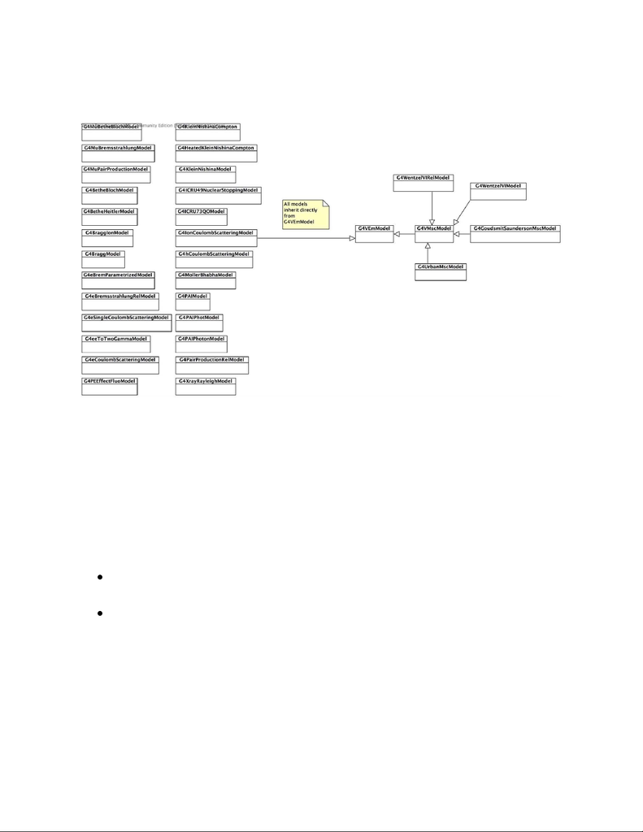

Fig. 32 Design of EM physics models.

The base class G4VEmModel has a lot of virtual methods mostly with the

default implementation. Pure virtual methods to be implemented in each

model class are following:

Initialise(const G4ParticleDefinition*, const

G4DataVector&);

SampleSecondaries(std::vector<G4DynamicParticle*>*,const

G4MaterialCutsCouple*,const G4DynamicParticle*,G4double

tmin=0.0,G4double tmax=DBL_MAX).

Any model may have its own data structure or physics table. It is optimal to

share data between threads in multi-threaded mode. For that at initialisation

it is possible to check if initialisation is performed in master thread using a

method IsMaster(). In the master thread data of the model should be

initialised. A model initialisation may be performed between runs. In that

case, potentially materials and cuts may be changed, so re-initialisation of

model data should be foreseen. In worker thread it is possible to access

shared data implementing virtual method InitialiseLocal(const

G4ParticleDefinition*, G4VEmModel* masterModel). It is strongly

recommended that a model class cannot change EM parameters in

G4EmParameters class or status of the de-excitation module. EM parameters

can be modified in physics lists or via UI commands.

Footnotes

[figure not shown]

Hadronic Physics

Introduction

Optimal exploitation of hadronic final states played a key role in successes

of all recent collider experiment in HEP, and the ability to use hadronic

final states will continue to be one of the decisive issues during the analysis

phase of the LHC experiments. Monte Carlo programs like Geant4 facilitate

the use of hadronic final states, and have been developed for many years.

We give an overview of the Object Oriented frameworks for hadronic

generators in Geant4, and illustrate the physics models underlying hadronic

shower simulation on examples, including the three basic types of

modeling; data-driven, parametrisation-driven, and theory-driven modeling,

and their possible realisations in the Object Oriented component system of

Geant4. We put particular focus on the level of extendibility that can and

has been achieved by our Russian dolls approach to Object Oriented design,

and the role and importance of the frameworks in a component system.

Principal Considerations

The purpose of this section is to explain the implementation frameworks

used in and provided by Geant4 for hadronic shower simulation as in the

1.1 release of the program. The implementation frameworks follow the

Russian dolls approach to implementation framework design. A top-level,

very abstracting implementation framework provides the basic interface to

the other Geant4 categories, and fulfills the most general use-case for

hadronic shower simulation. It is refined for more specific use-cases by

implementing a hierarchy of implementation frameworks, each level

implementing the common logic of a particular use-case package in a

concrete implementation of the interface specification of one framework

level above, this way refining the granularity of abstraction and delegation.

This defines the Russian dolls architectural pattern. Abstract classes are